# Open Case Studies: Exploring CO2 emissions across time

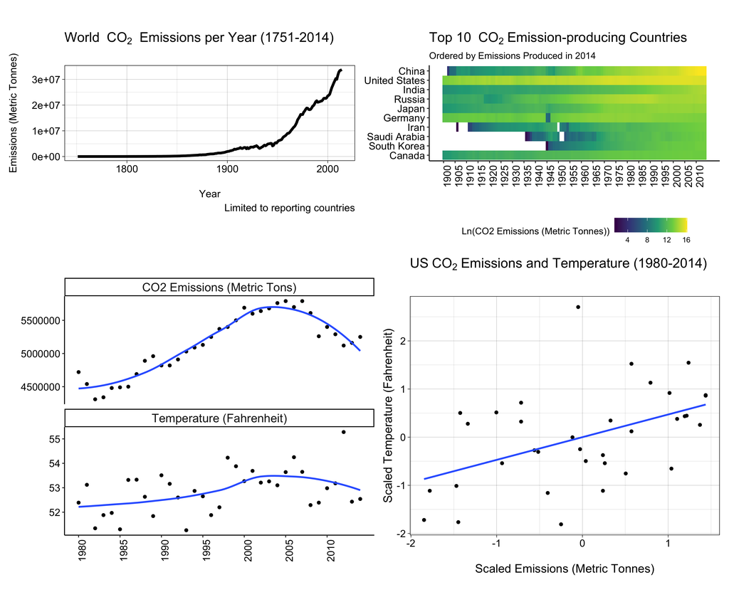

**Disclaimer**: The purpose of the [Open Case Studies](https://opencasestudies.github.io) project is **to demonstrate the use of various data science methods, tools, and software in the context of messy, real-world data**. A given case study does not cover all aspects of the research process, is not claiming to be the most appropriate way to analyze a given dataset, and should not be used in the context of making policy decisions without external consultation from scientific experts.

This work is licensed under the Creative Commons Attribution-NonCommercial 3.0 [(CC BY-NC 3.0)](https://creativecommons.org/licenses/by-nc/3.0/us/) United States License.

To cite this case study please use:

Wright, Carrie and Ontiveros, Michael and Jager, Leah and Taub, Margaret and Hicks, Stephanie. (2020). https://github.com/opencasestudies/ocs-bp-co2-emissions. Exploring CO2 emissions across time (Version v1.0.0).

To access the GitHub repository for this case study see here: https://github.com//opencasestudies/ocs-bp-co2-emissions.

You may also access and download the data using our `OCSdata` package. To learn more about this package including examples, see this [link](https://github.com/opencasestudies/OCSdata). Here is how you would install this package:

```r
install.packages("OCSdata")
```

This case study is part of a series of public health case studies for the [Bloomberg American Health Initiative](https://americanhealth.jhu.edu/open-case-studies).

The total reading time for this case study is calculated via koRpus and shown below:

| Reading Time | Method |
| --- | --- |
| 70 minutes | koRpus |

**Readability Score:**

A readability index estimates the reading difficulty level of a particular text. Flesch-Kincaid, FORCAST, and SMOG are three common readability indices that were calculated for this case study via koRpus. These indices provide an estimation of the minimum reading level required to comprehend this case study by grade and age.

```
Text language: en
```

| index | grade | age |
| --- | --- | --- |
| Flesch-Kincaid | 9 | 14 |
| FORCAST | 10 | 15 |
| SMOG | 11 | 16 |

Please help us by filling out our survey.

[interactive chart not shown]

# **Motivation**

This case study explores how different countries have contributed to Carbon Dioxide (CO2) emissions over time and how CO2 emission rates may relate to increasing global temperatures and increased rates of natural disasters and storms. We used this [report from the EPA](https://www.epa.gov/report-environment/greenhouse-gases) as the basis for motivating this case study, as it provides background information about how CO2 emissions and other greenhouse gases have influenced the climate and weather patterns.

CO2 makes up the largest proportion of greenhouse gas emissions in the United States:

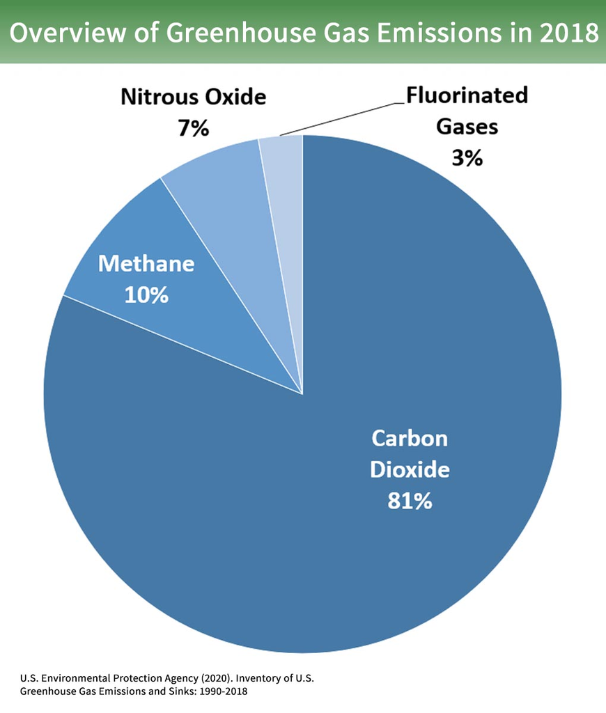

##### [[source]](https://www.epa.gov/ghgemissions/inventory-us-greenhouse-gas-emissions-and-sinks)

A variety of sources and sectors contribute to greenhouse gas emissions:

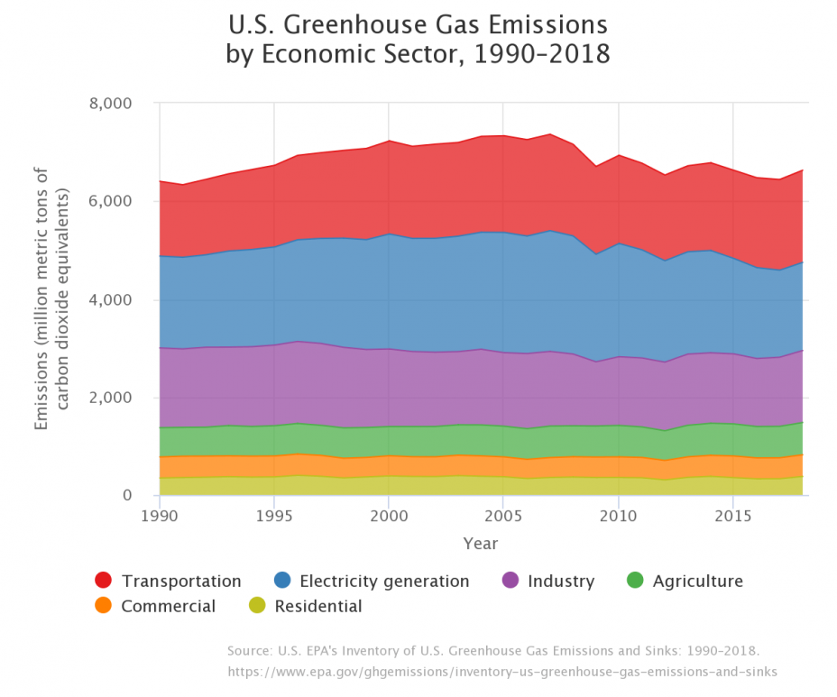

##### [[source]](https://www.epa.gov/ghgemissions/inventory-us-greenhouse-gas-emissions-and-sinks)

Transportation and Electricity contribute the most metric tons of CO2:

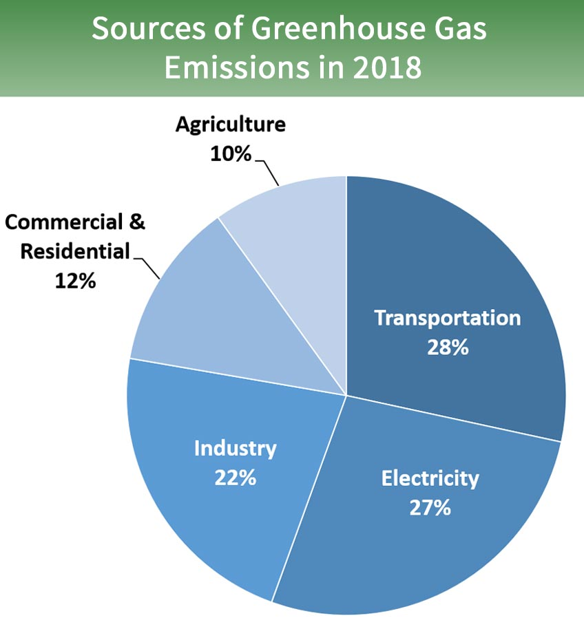

##### [[source]](https://www.epa.gov/ghgemissions/inventory-us-greenhouse-gas-emissions-and-sinks)

So why should we pay attention to greenhouse gases?

According to the [US Environmental Protection Agency (EPA) Inventory of U.S. Greenhouse Gas Emissions and Sinks 2020 Report](https://www.epa.gov/sites/production/files/2020-04/documents/us-ghg-inventory-2020-main-text.pdf):

> Greenhouse gases absorb infrared radiation, thereby trapping heat in the atmosphere and making the planet warmer. The most important greenhouse gases directly emitted by humans include carbon dioxide (CO2), methane (CH4), nitrous oxide (N2O), and several fluorine-containing halogenated substances. Although CO2, CH4, and N2O occur naturally in the atmosphere, human activities have changed their atmospheric concentrations. From the pre- industrial era (i.e., ending about 1750) to 2018, concentrations of these greenhouse gases have increased globally by 46, 165, and 23 percent, respectively (IPCC 2013; NOAA/ESRL 2019a, 2019b, 2019c).

* IPCC stands for the Intergovernmental Panel on Climate Change

In fact, there are many signs that our planet is experiencing warmer temperatures:

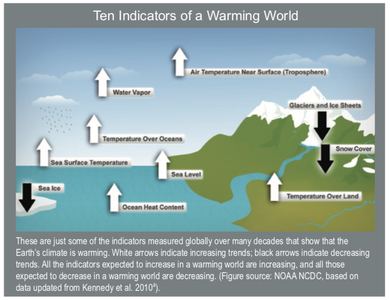

##### [[source]](https://data.globalchange.gov/report/nca3-overview)

The connection between greenhouse gas levels and global temperatures and the influence of increased global temperatures on human health are motivated by these reports:

- Melillo, J.M., T.C. Richmond, and G.W. Yohe (eds.). 2014. Climate change impacts in the United States: The third National Climate Assessment. U.S. Global Change Research Program.
- 2020. “Inventory of US Greenhouse Gas Emissions and Sinks: 1990–2018.” EPA 430-R-20-002, Tech. Rep. https://www.epa.gov/ghgemissions/inventory-us-greenhouse-gas-emissions-and-sinks.

The [National Climate Assessment Report](https://data.globalchange.gov/report/nca3-overview) states that:

> Heat-trapping gases already in the atmosphere have committed us to a hotter future with more climate-related impacts over the next few decades. The magnitude of climate change beyond the next few decades depends primarily on the amount of heat-trapping gases that human activities emit globally, now and in the future.

See the following links for more information about how greenhouse gases have influenced global temperatures: 1) The EPA [report](https://www.epa.gov/report-environment/greenhouse-gases) on green house gases  
2) The National Climate Assessment (NCA) [summary from 2014](https://nca2014.globalchange.gov/)) 3) The [World101 website](https://world101.cfr.org/global-era-issues/climate-change/climate-change-adaptations) about how countries are adapting to climate change

# **Main Questions**

**Our main questions:**

1. How have global CO2 emission rates changed over time? In particular for the US, and how does the US compare to other countries?
2. Are CO2 emissions in the US, global temperatures, and natural disaster rates in the US associated?

# **Learning Objectives**

In this case study, we will explore CO2 emission data from around the world. We will also focus on the US specifically to evaluate patterns of temperatures and natural disaster activity.

This case study will particularly focus on how to use different datasets that span different ranges of time, as well as how to create visualizations of patterns over time. We will especially focus on using packages and functions from the [`tidyverse`](https://www.tidyverse.org/), such as `dplyr`, `tidyr`, and `ggplot2`.

The tidyverse is a library of packages created by RStudio. While some students may be familiar with previous R programming packages, these packages make data science in R especially legible and intuitive.

The skills, methods, and concepts that students will be familiar with by the end of this case study are:

**Data Science Learning Objectives:**

1. Importing data from various types of Excel files and CSV files
2. Apply action verbs in `dplyr` for data wrangling
3. How to pivot between “long” and “wide” datasets
4. Joining together multiple datasets using `dplyr`
5. How to create effective longitudinal data visualizations with `ggplot2`
6. How to add text, color, and labels to `ggplot2` plots
7. How to create faceted `ggplot2` plots

**Statistical Learning Objectives:**

1. Introduction to correlation coefficient as a summary statistic
2. Relationship between correlation and linear regression
3. Correlation is not causation

[figure not shown]

We will begin by loading the packages that we will need:

```r
library(here)
library(readxl)
library(readr)
library(dplyr)
library(magrittr)
library(stringr)
library(purrr)
library(tidyr)
library(forcats)
library(ggplot2)
library(directlabels)
library(ggrepel)
library(broom)
library(patchwork)
library(OCSdata)
```

**Packages used in this case study:**

| Package | Use in this case study |
| --- | --- |
| [`here`](https://github.com/jennybc/here_here) | to easily load and save data |
| [`readxl`](https://readxl.tidyverse.org/) | to import the Excel file data |
| [`readr`](https://readr.tidyverse.org/) | to import the csv file data |
| [`dplyr`](https://dplyr.tidyverse.org/) | to view and wrangle the data, by modifying variables, renaming variables, selecting variables, creating variables, and arranging values within a variable |
| [`magrittr`](https://cran.r-project.org/web/packages/magrittr/vignettes/magrittr.html) | to use data objects using the `%>%` pipe operator |
| [`stringr`](https://stringr.tidyverse.org/) | to select only the first 4 characters of date data |
| [`purrr`](https://purrr.tidyverse.org/) | to apply a function on a list of tibbles (tibbles are the tidyverse version of a data frame) |
| [`tidyr`](https://tidyr.tidyverse.org/) | to drop rows with `NA` values from a tibble |
| [`forcats`](https://forcats.tidyverse.org/) | to reorder the levels of a factor |
| [`ggplot2`](https://ggplot2.tidyverse.org/) | to make visualizations |
| [`directlabels`](http://directlabels.r-forge.r-project.org/docs/index.html) | to add labels to plots easily |
| [`ggrepel`](https://cran.r-project.org/web/packages/ggrepel/vignettes/ggrepel.html) | to add labels that don’t overlap to plots |
| [`broom`](https://www.tidyverse.org/blog/2018/07/broom-0-5-0/) | to make the output form statistical tests easier to work with |
| [`patchwork`](https://github.com/thomasp85/patchwork) | to combine plots |
| [`OCSdata`](https://github.com/opencasestudies/OCSdata) | to access and download OCS data files |

The first time we use a function, we will use the `::` to indicate which package we are using. Unless we have overlapping function names, this is not necessary, but we will include it here to be informative about where the functions we will use come from.

# **Context**

Now we will describe a bit more background about greenhouse gas emissions and the potential influence of these emissions on public health.

Greenhouse gas emissions are due to both natural processes and anthropogenic (human-derived) activities.

These emissions are one of the contributing factors to rising global temperatures, which can have a great influence on [public health](https://www.epa.gov/climate-indicators/understanding-connections-between-climate-change-and-human-health) as illustrated in the following image:

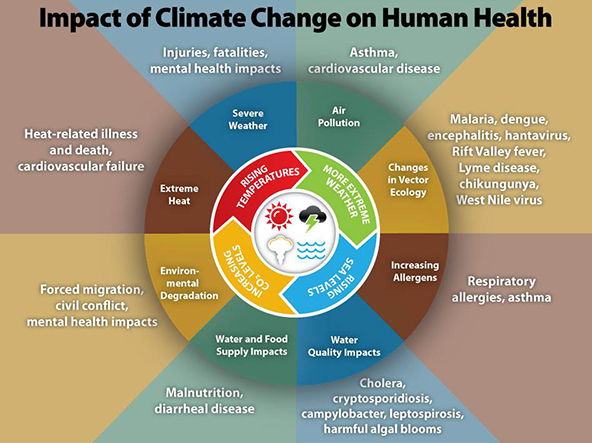

##### [[source]](https://www.cdc.gov/climateandhealth/effects/default.htm)

According to the [US Environmental Protection Agency (EPA) Inventory of U.S. Greenhouse Gas Emissions and Sinks 2020 Report](https://www.epa.gov/sites/production/files/2020-04/documents/us-ghg-inventory-2020-main-text.pdf):

> Gases in the atmosphere can contribute to climate change both directly and indirectly. Direct effects occur when the gas itself absorbs radiation. Indirect radiative forcing occurs when chemical transformations of the substance produce other greenhouse gases, when a gas influences the atmospheric lifetimes of other gases, and/or when a gas affects atmospheric processes that alter the radiative balance of the earth (e.g., affect cloud formation or [albedo](https://en.wikipedia.org/wiki/Albedo)).

The **Global Warming Potential (GWP)** compares the **ability of a greenhouse gas to trap heat in the atmosphere relative to another gas**.

> The GWP of a greenhouse gas is defined as the ratio of the accumulated radiative forcing within a specific time horizon caused by emitting 1 kilogram of the gas, relative to that of the reference gas CO2 (IPCC 2013). Therefore GWP-weighted emissions are provided in million metric tons of CO2 equivalent (MMT CO2 Eq.)

##### [[source]](https://www.epa.gov/sites/production/files/2020-04/documents/us-ghg-inventory-2020-main-text.pdf)

CO2 is actually the least heat-trapping gas of the greenhouse gases:

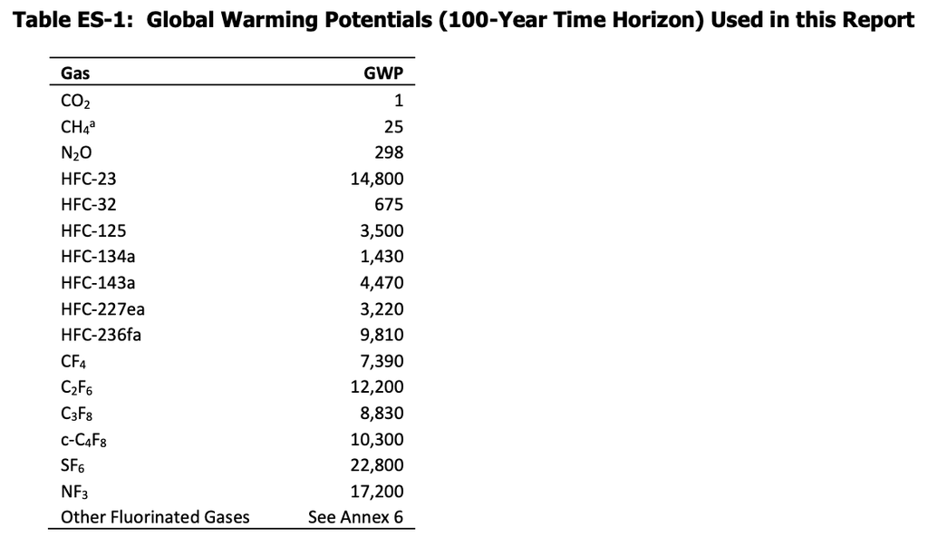

##### [[source]](https://www.epa.gov/sites/production/files/2020-04/documents/us-ghg-inventory-2020-main-text.pdf)

However, because CO2 is so much more abundant and stays in the atmosphere so much longer than other greenhouse gases, it has been the largest contributor to global warming. See here for more details.

It is also important to keep in mind that there is a [lag](https://earthobservatory.nasa.gov/blogs/climateqa/would-gw-stop-with-greenhouse-gases/) between greenhouse gas emissions and temperature changes that we experience because much of Earth’s thermal energy (and CO2) gets stored in the ocean.

Due to a process called [thermal inertia](https://en.wikipedia.org/wiki/Volumetric_heat_capacity#Thermal_inertia), the heat stored in the ocean will eventually be transfered to the surface of the Earth long after the gases were emitted that resulted in the increased ocean temperature.

See [here](https://earthobservatory.nasa.gov/blogs/climateqa/would-gw-stop-with-greenhouse-gases/) for more explanation.

Furthermore, rising CO2 levels in the ocean also influence ocean acidity:

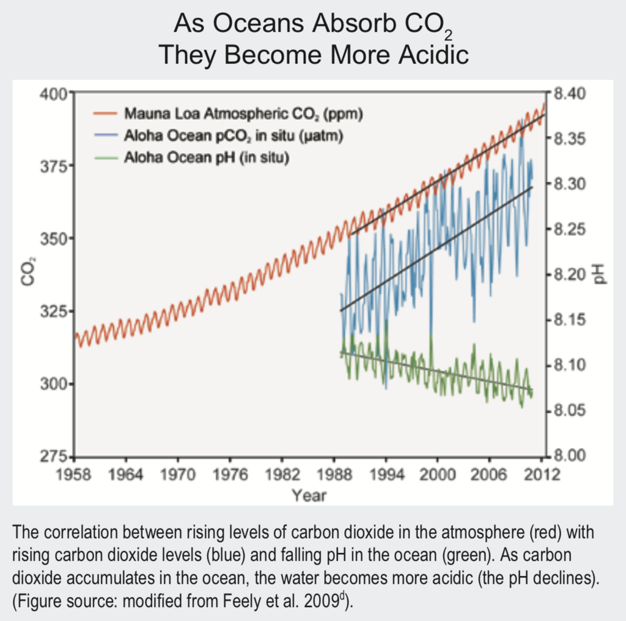

##### [[source]](https://data.globalchange.gov/report/nca3-overview)

As CO2 levels rise in the ocean, the pH becomes more acidic, which makes it difficult for organisms to maintain their shells or skeletons that are made of calcium carbonate, thus making it more difficult for these organisms to survive and impacting their role in the ecosystem and food chain.

Furthermore, greenhouse gas emissions are believed to influence weather patterns as shown in this [report](https://data.globalchange.gov/report/nca3-overview).

Indeed, events with high levels of precipitation which can induce flooding and property damage are generally increasing around the country:

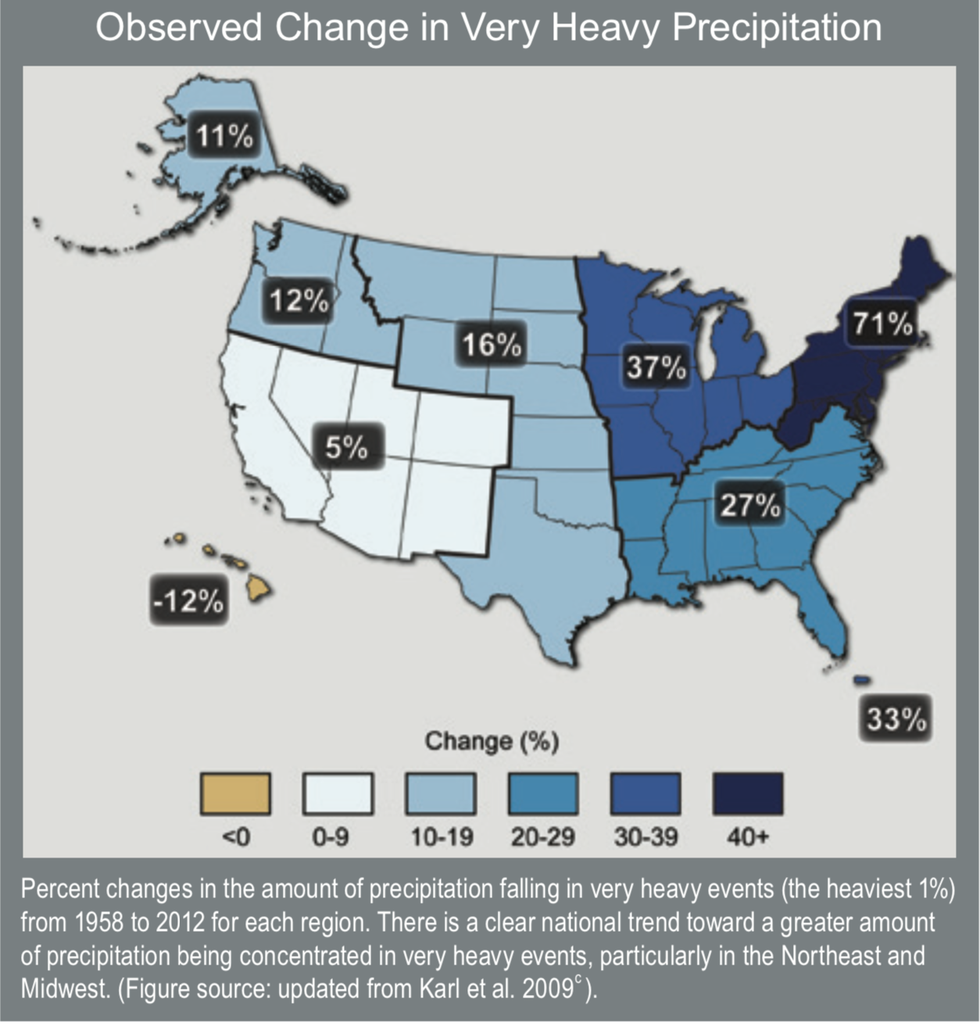

##### [[source]](https://data.globalchange.gov/report/nca3-overview)

# **Limitations**

An important limitation regarding this data analysis to keep in mind is the datasets only include countries and years in which countries were reporting such information to the agencies that collected the data. Thus, the data are incomplete. For example, while we have a fairly good sense of CO2 emissions globally for later years, additional emissions were also produced by countries that are not included in the data.

# **What are the data?**

In this case study we will be using data related to CO2 emissions, as well as other data that may influence, be influenced or relate to CO2 emissions. Most of our data is from [Gapminder](https://www.gapminder.org/data/) that was originally obtained from the [World Bank](https://www.worldbank.org/en/what-we-do).

In addition, we will use some data that is specific to the United States from the [National Oceanic and Atmospheric Administration (NOAA)](https://www.noaa.gov/), which is an agency that collects weather and climate data.

| Data | Time span | Source | Original Source | Description | Citation |
| --- | --- | --- | --- | --- | --- |
| **CO2 emissions** | 1751-2014 | [Gapminder](https://www.gapminder.org/data/) | [Carbon Dioxide Information Analysis Center (CDIAC)](https://cdiac.ess-dive.lbl.gov/) | CO2 emissions in tonnes or metric tons (equivalent to approximately 2,204.6 pounds) per person by country | NA |
| **GDP per capita (percent yearly growth)** | 1801-2019 | [Gapminder](https://www.gapminder.org/data/) | [World Bank](https://data.worldbank.org/indicator/NY.GDP.PCAP.KD.ZG) | Growth Domestic Product (which is an overall measure of the health of nation’s economy) per person by country | NA |
| **Energy use per person** | 1960-2015 | [Gapminder](https://www.gapminder.org/data/) | [World Bank](https://data.worldbank.org/indicator/EG.USE.PCAP.KG.OE) | Use of primary energy before transformation to other end-use fuels, by country | NA |
| **US Natural Disasters** | 1980-2019 | [The National Oceanic and Atmospheric Administration (NOAA)](https://www.ncdc.noaa.gov/billions/time-series) | [The National Oceanic and Atmospheric Administration (NOAA)](https://www.ncdc.noaa.gov/billions/time-series) | US data about: – Droughts – Floods – Freezes – Severe Storms – Tropical Cyclones – Wildfires – Winter Storms | NOAA National Centers for Environmental Information (NCEI) U.S. Billion-Dollar Weather and Climate Disasters (2020). https://www.ncdc.noaa.gov/billions/, DOI: 10.25921/stkw-7w73 |
| **Temperature** | 1895-2019 | [The National Oceanic and Atmospheric Administration (NOAA)](https://www.ncdc.noaa.gov/cag/national/time-series) | [The National Oceanic and Atmospheric Administration (NOAA)](https://www.ncdc.noaa.gov/cag/national/time-series) | US National yearly average temperature (in Fahrenheit) from 1895 to 2019 | NOAA National Centers for Environmental information, Climate at a Glance: National Time Series, published June 2020, retrieved on June 26, 2020 from https://www.ncdc.noaa.gov/cag/ |

To obtain the temperature data, the annual average temperatures were selected as shown in this image:

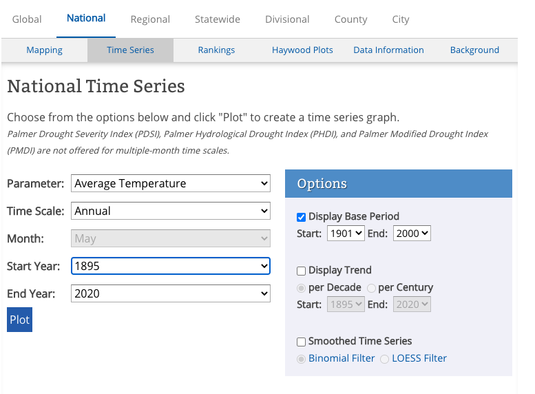

##### [[source]](https://www.ncdc.noaa.gov/cag/national/time-series)

Importantly, notice that the data we would like to use span different time periods:

| Data | Time span |
| --- | --- |
| **CO2 emissions** | 1751 to 2014 |
| **GDP per capita (yearly growth)** | 1801 to 2019 |
| **Energy use per person** | 1960 to 2015 |
| **US Natural Disasters** | 1980 to 2019 |
| **Temperature** | 1895 to 2019 |

We will explore more about this a bit later.

**Question Opportunity**

What concerns might arise about reliability and variation of measurement practices over time?

# **Data Import**

In our case, we downloaded the data for the files from the various sources as indicated in the table above and put them within a “raw” subdirectory of a “data” directory for our project. If you use an RStudio project, then you can use the `here()` function of the `here` package to make the path for importing this data simpler. The `here` package automatically starts looking for files based on where you have a `.Rproj` file which is created when you start a new RStudio project. We can specify that we want to look for the “yearly_co2_emissions_1000_tonnes.xlsx” file within the “raw” directory within the “data” directory within a directory where our `.Rproj` file is located by separating the names of these directories using commas and listing “data” first.

**Click here to see more about creating new projects in RStudio.**

See [here](https://support.rstudio.com/hc/en-us/articles/200526207-Using-Projects) to learn more about using RStudio projects and here to learn more about the `here` package.

To read in the files that were downloaded from the various sources as indicated in the table above, we will use the `read_xlsx()` and `read_xls()` functions of the `readxl` package to import the data from the `.xlsx` and `.xls` files, respectively. We will also use the `here()` function of the `here` package to more easily specify the path to our files relative to the directory where the .Rproj file is located.

```r
CO2_emissions <- readxl::read_xlsx(here("data","raw", "yearly_co2_emissions_1000_tonnes.xlsx"))
gdp_growth    <- readxl::read_xlsx(here("data", "raw", "gdp_per_capita_yearly_growth.xlsx"))
energy_use    <- readxl::read_xlsx(here("data", "raw", "energy_use_per_person.xlsx"))
```

If you had trouble downloading these files, you can do so at our [GitHub repo](https://github.com//opencasestudies/ocs-bp-co2-emissions/tree/master/data/raw/) or more directly by clicking [here](https://raw.githubusercontent.com/opencasestudies/ocs-bp-co2-emissions/master/data/raw/yearly_co2_emissions_1000_tonnes.xlsx), [here](https://raw.githubusercontent.com/opencasestudies/ocs-bp-co2-emissions/master/data/raw/gdp_per_capita_yearly_growth.xlsx), and [here](https://raw.githubusercontent.com/opencasestudies/ocs-bp-co2-emissions/master/data/raw/energy_use_per_person.xlsx).

You may also download these files using the `OCSdata` package:

```r
# install.packages("OCSdata")
# You will need to install the package if you haven't already done so.
library(OCSdata)
raw_data("ocs-bp-co2-emissions", outpath = getwd())
# This will save the raw data files in a "OCSdata/data/raw/" subfolder
# in your current working directory
```

We will use the `read_csv()` function of the `readr` package to import the data from the `.csv` files.

However, for these files there are some lines that we would like to not import because the number of columns differ for some rows. If we don’t account for this, then we may end up importing fewer columns of the data that we would like.

In the first 5 rows shown below in the `data/disasters.csv` file, you can see that the first two rows does not have the same number of columns as the subsequent rows and are just (sub)titles.

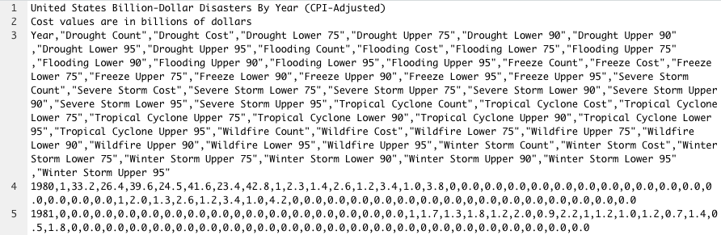

To do this, we can skip rows using the `skip = 2` argument of the `read_csv()` function.

```r
us_disaster <- readr::read_csv(here("data", "raw", "disasters.csv"), skip = 2)
```

If you had trouble downloading this file, you can do so at our [GitHub repo](https://github.com//opencasestudies/ocs-bp-co2-emissions/tree/master/data/raw) or more directly by clicking [here](https://raw.githubusercontent.com/opencasestudies/ocs-bp-co2-emissions/master/data/raw/disasters.csv).

Now looking at the `data/temperature.csv` file, we see that the first four lines do not have the same number of columns as the subsequent lines.

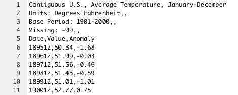

We will skip importing all 4 lines by using `skip = 4`. We can also replace all instances of `"-99"` with `NA` using the `na = "-99"` argument of the `read_csv()` function. The “-99” needs to be in quotation marks because this argument expects characters.

**Click here for an explanation about data types in R and about character strings.**

There are several classes of data in R programming, meaning that certain objects will be treated or interpreted differently. Character is one of these classes. A character string is an individual data value made up of characters. This can be a paragraph, like the legend for the table, or it can be a single letter or number like the letter “a” or the number “3”. If data are of class character, than the numeric values will not be processed like a numeric value in a mathematical sense. If you want your numeric values to be interpreted that way, they need to be converted to a numeric class. The options typically used are integer (which has no decimal place) and double precision (which has a decimal place).

A variable that is a factor has a set of particular values called levels (this can be numbers or characters). Even if these are numeric, they will be interpreted as levels (i.e., as if they were characters) not as mathematical numbers. The values of a factor are assumed to have a particular ordering; by default the order is alphabetical, but this is not always the correct/intuitive ordering. You can modify the order of these levels with the `forcats` package.

```r
us_temperature <- readr::read_csv(here("data", "raw", "temperature.csv"), skip = 4, na = "-99")
```

If you had trouble downloading this file, you can do so at our [GitHub repo](https://github.com//opencasestudies/ocs-bp-co2-emissions/tree/master/data/raw) or more directly by clicking [here](https://raw.githubusercontent.com/opencasestudies/ocs-bp-co2-emissions/master/data/raw/temperature.csv).

Great! now we have imported all of the data that we will need.

To allow users to skip import we will save the data as an RDA file:

```r
save(CO2_emissions,
     gdp_growth,
     energy_use,
     us_disaster,
     us_temperature,
     file = here::here("data", "imported", "co2_data_imported.rda"))
```

# **Data Wrangling**

If you have been following along but stopped, we could load our imported data like so:

```r
load(here::here("data", "imported", "co2_data_imported.rda"))
```

**If you skipped the data import section click here.**

First you need to install and load the `OCSdata` package:

```r
# install.packages("OCSdata")
# You will need to install the package if you haven't already done so.
library(OCSdata)
```

Then, you may load the imported data using the following code:

```r
imported_data("ocs-bp-co2-emissions", outpath = getwd())
load(here::here("OCS_data", "data", "imported", "co2_data_imported.rda"))
```

If the package does not work for you, alternatively, an RDA file (stands for R data) of the data can be found [here](https://github.com//opencasestudies/ocs-bp-co2-emissions/tree/master/data/imported) or slightly more directly [here](https://raw.githubusercontent.com/opencasestudies/ocs-bp-co2-emissions/master/data/imported/co2_data_imported.rda). Download this file and then place it in your current working directory within a subdirectory called “imported” within a directory called “data” to copy and paste our code. We used an RStudio project and the [`here` package](https://github.com/jennybc/here_here) to navigate to the file more easily.

```r
load(here::here("data", "imported", "co2_data_imported.rda"))
```

**Click here to see more about creating new projects in RStudio.**

See [here](https://support.rstudio.com/hc/en-us/articles/200526207-Using-Projects) to learn more about using RStudio projects and here to learn more about the `here` package.

Next, we take a look at our data that we just imported. We will need to do some data wrangling to allow us to evaluate how CO2 emissions have changed over time and how emissions may relate to energy use, GDP, etc. Let’s explore how to do that with useful functions and packages from the `tidyverse`.

## **Yearly CO<sub>2</sub> Emissions**

First, let’s take a look at the CO2 data (`CO2_emissions`). We can use the `slice_head()` function of the `dplyr` package to see just the first rows of our data. We can specify how many rows we would like to see by using the `n =` argument.

We will use the `%>%` pipe from the `magrittr` package (although it is also imported by other `tidyverse` packages, like `dplyr`), which can be used to define the input for later sequential steps. This will make more sense when we have multiple sequential steps using the same data object.

```r
CO2_emissions %>%
  slice_head(n = 3)
```

```
# A tibble: 3 × 265
  country  `1751` `1752` `1753` `1754` `1755` `1756` `1757` `1758` `1759` `1760`
  <chr>     <dbl>  <dbl>  <dbl>  <dbl>  <dbl>  <dbl>  <dbl>  <dbl>  <dbl>  <dbl>
1 Afghani…     NA     NA     NA     NA     NA     NA     NA     NA     NA     NA
2 Albania      NA     NA     NA     NA     NA     NA     NA     NA     NA     NA
3 Algeria      NA     NA     NA     NA     NA     NA     NA     NA     NA     NA
# ℹ 254 more variables: `1761` <dbl>, `1762` <dbl>, `1763` <dbl>, `1764` <dbl>,
#   `1765` <dbl>, `1766` <dbl>, `1767` <dbl>, `1768` <dbl>, `1769` <dbl>,
#   `1770` <dbl>, `1771` <dbl>, `1772` <dbl>, `1773` <dbl>, `1774` <dbl>,
#   `1775` <dbl>, `1776` <dbl>, `1777` <dbl>, `1778` <dbl>, `1779` <dbl>,
#   `1780` <dbl>, `1781` <dbl>, `1782` <dbl>, `1783` <dbl>, `1784` <dbl>,
#   `1785` <dbl>, `1786` <dbl>, `1787` <dbl>, `1788` <dbl>, `1789` <dbl>,
#   `1790` <dbl>, `1791` <dbl>, `1792` <dbl>, `1793` <dbl>, `1794` <dbl>, …
```

Another useful function is `slice_sample()` to look at a **selection of random rows** using [pseudorandom](https://en.wikipedia.org/wiki/Pseudorandomness) numbers for the index of rows to show. To continue to get the same random values or for others to get the same values, we need to set a seed first. We can do this with the `set.seed()` base function. We just specify a number with this function and that will allow us to get the same subset of values from the `slice_sample()` function. If two different people ran this code (without set.seed()), they would each see a different subset of rows. For data exploration, this isn’t a huge deal, but if we’d like separate analysts running the same code to see the same output, we will use set.seed(). If we changed set.seed(123) to set.seed(333), we would obtain a different random sample of rows.

```r
set.seed(123)

CO2_emissions %>%
  slice_sample(n = 3)
```

```
# A tibble: 3 × 265
  country  `1751` `1752` `1753` `1754` `1755` `1756` `1757` `1758` `1759` `1760`
  <chr>     <dbl>  <dbl>  <dbl>  <dbl>  <dbl>  <dbl>  <dbl>  <dbl>  <dbl>  <dbl>
1 Sri Lan…     NA     NA     NA     NA     NA     NA     NA     NA     NA     NA
2 Tuvalu       NA     NA     NA     NA     NA     NA     NA     NA     NA     NA
3 Banglad…     NA     NA     NA     NA     NA     NA     NA     NA     NA     NA
# ℹ 254 more variables: `1761` <dbl>, `1762` <dbl>, `1763` <dbl>, `1764` <dbl>,
#   `1765` <dbl>, `1766` <dbl>, `1767` <dbl>, `1768` <dbl>, `1769` <dbl>,
#   `1770` <dbl>, `1771` <dbl>, `1772` <dbl>, `1773` <dbl>, `1774` <dbl>,
#   `1775` <dbl>, `1776` <dbl>, `1777` <dbl>, `1778` <dbl>, `1779` <dbl>,
#   `1780` <dbl>, `1781` <dbl>, `1782` <dbl>, `1783` <dbl>, `1784` <dbl>,
#   `1785` <dbl>, `1786` <dbl>, `1787` <dbl>, `1788` <dbl>, `1789` <dbl>,
#   `1790` <dbl>, `1791` <dbl>, `1792` <dbl>, `1793` <dbl>, `1794` <dbl>, …
```

**Question Opportunity**

Try setting a different seed to see the difference in the output.

OK, we see each country is represented along one row and each column contains yearly CO2 emissions. We also see that there are a lot of `NA` values.

We can also use the `glimpse()` function of the `dplyr` package to view our data. This allows us to see all of our variables at once. We will see a tiny bit of each variable/column with the data displayed on the right.

```r
# Scroll through the output!
CO2_emissions %>%
  dplyr::glimpse()
```

```
Rows: 192
Columns: 265
$ country <chr> "Afghanistan", "Albania", "Algeria", "Andorra", "Angola", "Ant…
$ `1751`  <dbl> NA, NA, NA, NA, NA, NA, NA, NA, NA, NA, NA, NA, NA, NA, NA, NA…
$ `1752`  <dbl> NA, NA, NA, NA, NA, NA, NA, NA, NA, NA, NA, NA, NA, NA, NA, NA…
$ `1753`  <dbl> NA, NA, NA, NA, NA, NA, NA, NA, NA, NA, NA, NA, NA, NA, NA, NA…
$ `1754`  <dbl> NA, NA, NA, NA, NA, NA, NA, NA, NA, NA, NA, NA, NA, NA, NA, NA…
$ `1755`  <dbl> NA, NA, NA, NA, NA, NA, NA, NA, NA, NA, NA, NA, NA, NA, NA, NA…
$ `1756`  <dbl> NA, NA, NA, NA, NA, NA, NA, NA, NA, NA, NA, NA, NA, NA, NA, NA…
$ `1757`  <dbl> NA, NA, NA, NA, NA, NA, NA, NA, NA, NA, NA, NA, NA, NA, NA, NA…
$ `1758`  <dbl> NA, NA, NA, NA, NA, NA, NA, NA, NA, NA, NA, NA, NA, NA, NA, NA…
$ `1759`  <dbl> NA, NA, NA, NA, NA, NA, NA, NA, NA, NA, NA, NA, NA, NA, NA, NA…
$ `1760`  <dbl> NA, NA, NA, NA, NA, NA, NA, NA, NA, NA, NA, NA, NA, NA, NA, NA…
$ `1761`  <dbl> NA, NA, NA, NA, NA, NA, NA, NA, NA, NA, NA, NA, NA, NA, NA, NA…
$ `1762`  <dbl> NA, NA, NA, NA, NA, NA, NA, NA, NA, NA, NA, NA, NA, NA, NA, NA…
```

[output cut: 252 more lines]

We can also see that we have a large [tibble](https://tibble.tidyverse.org/).

```r
CO2_emissions %>%
  class()
```

```
[1] "tbl_df"     "tbl"        "data.frame"
```

This is the object that is created when we read in the data with `readr`. A tibble (or `tbl_df`) is the `tidyverse` version of a `data.frame` object. Similar to `data.frame`, it is a table with variable information arranged as columns, and individual observations arranged as rows. However some nice differences are they do not change variable names or data types and they give more messages when something is wrong (e.g. when a variable does not exist), which forces the analyst to confront problems earlier. Tibbles also give us information about the class of each variable.

For example the `country` variable is made up of character (abbreviated as `chr`) values.

```r
CO2_emissions %>%
  select(country)
```

```
# A tibble: 192 × 1
   country
   <chr>
 1 Afghanistan
 2 Albania
 3 Algeria
 4 Andorra
 5 Angola
 6 Antigua and Barbuda
 7 Argentina
 8 Armenia
 9 Australia
10 Austria
# ℹ 182 more rows
```

We see that we have 192 rows different country variables and CO2 emission values for 264 different years (from 1751 to 2014).

```r
names(CO2_emissions)
```

```
  [1] "country" "1751"    "1752"    "1753"    "1754"    "1755"    "1756"
  [8] "1757"    "1758"    "1759"    "1760"    "1761"    "1762"    "1763"
 [15] "1764"    "1765"    "1766"    "1767"    "1768"    "1769"    "1770"
 [22] "1771"    "1772"    "1773"    "1774"    "1775"    "1776"    "1777"
 [29] "1778"    "1779"    "1780"    "1781"    "1782"    "1783"    "1784"
 [36] "1785"    "1786"    "1787"    "1788"    "1789"    "1790"    "1791"
 [43] "1792"    "1793"    "1794"    "1795"    "1796"    "1797"    "1798"
 [50] "1799"    "1800"    "1801"    "1802"    "1803"    "1804"    "1805"
 [57] "1806"    "1807"    "1808"    "1809"    "1810"    "1811"    "1812"
 [64] "1813"    "1814"    "1815"    "1816"    "1817"    "1818"    "1819"
 [71] "1820"    "1821"    "1822"    "1823"    "1824"    "1825"    "1826"
 [78] "1827"    "1828"    "1829"    "1830"    "1831"    "1832"    "1833"
 [85] "1834"    "1835"    "1836"    "1837"    "1838"    "1839"    "1840"
 [92] "1841"    "1842"    "1843"    "1844"    "1845"    "1846"    "1847"
 [99] "1848"    "1849"    "1850"    "1851"    "1852"    "1853"    "1854"
```

[output cut: 23 more lines]

Recall, the values are emissions in metric tons, also called tonnes. Scrolling through the `glimpse()` function above, we can also see that there are fewer `NA` values for later years.

Right now our data is in what is called **“wide”** format. In wide format, each variable is listed as its own column. In contrast, in long format, variables maybe collapsed into a column that identifies the variables and a column of values. See [here](https://en.wikipedia.org/wiki/Wide_and_narrow_data) for more information about the difference between the two formats.

We want to collapse all of the values for the emission data across the different individual year variables into one new `Emissions` variable. We will identify what year they are from by creating a new `Year` variable. The `cols =` argument allows us to specify which columns we want to pivot (or not pivot) to create these new columns. We want to keep our `country` data as an ID variable so we will exclude it using the `-` sign, by default all other columns will be used.

```r
CO2_emissions <- CO2_emissions %>%
  pivot_longer(cols = -country,
               names_to = "Year",
               values_to = "Emissions")

set.seed(123)

CO2_emissions %>%
  slice_sample(n = 6)
```

```
# A tibble: 6 × 3
  country     Year  Emissions
  <chr>       <chr>     <dbl>
1 Bahamas     1832       NA
2 Montenegro  1843       NA
3 Mongolia    1892       NA
4 Samoa       1791       NA
5 Azerbaijan  1867       53.2
6 Timor-Leste 2010      235
```

**Question Opportunity**

Think a moment about what the dimensions of the `CO2_emissions` tibble are now and why? How would you check this?

**Hint** : Checking has something to do with a unique aspect about tibbles.

Let’s say we also want to rename the `country` variable to be capitalized. To do this, we can use the `rename()` function of the `dplyr` package to rename this variable. When renaming variables the syntax is `new-name = old-name`, where the new name is listed first before the `=`.

You may also note that the `Year` variable is currently of class type character. We would like to change it to be numeric. To do this we will use the `mutate()` function, which is also part of the `dplyr` package. This function allows us to create and modify variables. We will also use this function to create a variable called `Label` which will have `"CO2 Emissions (Metric Tons)"` as the value for every row, to be used when we create plots later.

```r
CO2_emissions  <- CO2_emissions %>%
   dplyr::rename(Country = country) %>%
   dplyr::mutate(Year = as.numeric(Year),
                 Label = "CO2 Emissions (Metric Tons)")
```

Now let’s take a look to see how our data has changed:

```r
set.seed(123)

CO2_emissions %>%
  slice_sample(n = 6)
```

```
# A tibble: 6 × 4
  Country      Year Emissions Label
  <chr>       <dbl>     <dbl> <chr>
1 Bahamas      1832      NA   CO2 Emissions (Metric Tons)
2 Montenegro   1843      NA   CO2 Emissions (Metric Tons)
3 Mongolia     1892      NA   CO2 Emissions (Metric Tons)
4 Samoa        1791      NA   CO2 Emissions (Metric Tons)
5 Azerbaijan   1867      53.2 CO2 Emissions (Metric Tons)
6 Timor-Leste  2010     235   CO2 Emissions (Metric Tons)
```

Great, we can see that now the `Year` variable is of class double (abbreviated `dbl`), which is a numeric class.

Now, let’s take a look at the `Country` variable to check if there is anything unexpected. We will use the `distinct()` function of the `dplyr` package to view the unique values only. Finally, we use the `pull()` function of the `dplyr` package to extract the values from the column (this is similar to using the `$` base R syntax e.g. `CO2_emission$Country`).

```r
# Scroll through the output!
CO2_emissions %>%
  distinct(Country) %>%
  pull()
```

```
  [1] "Afghanistan"                    "Albania"
  [3] "Algeria"                        "Andorra"
  [5] "Angola"                         "Antigua and Barbuda"
  [7] "Argentina"                      "Armenia"
  [9] "Australia"                      "Austria"
 [11] "Azerbaijan"                     "Bahamas"
 [13] "Bahrain"                        "Bangladesh"
 [15] "Barbados"                       "Belarus"
 [17] "Belgium"                        "Belize"
 [19] "Benin"                          "Bhutan"
 [21] "Bolivia"                        "Bosnia and Herzegovina"
 [23] "Botswana"                       "Brazil"
 [25] "Brunei"                         "Bulgaria"
 [27] "Burkina Faso"                   "Burundi"
 [29] "Cambodia"                       "Cameroon"
```

[output cut: 81 more lines]

These all look as expected!

## **Yearly Growth in GDP per Capita**

Let’s take a look at the next dataset (`gdp_growth`) that we imported.

```r
gdp_growth %>%
  slice_head(n = 3)
```

```
# A tibble: 3 × 220
  country       `1801`   `1802`   `1803`   `1804`   `1805`   `1806`   `1807`
  <chr>          <dbl>    <dbl>    <dbl>    <dbl>    <dbl>    <dbl>    <dbl>
1 Afghanistan NA       NA       NA       NA       NA       NA       NA
2 Albania      0.104    0.104    0.104    0.104    0.104    0.104    0.104
3 Algeria     -0.00247 -0.00247 -0.00247 -0.00247 -0.00247 -0.00247 -0.00247
# ℹ 212 more variables: `1808` <dbl>, `1809` <dbl>, `1810` <dbl>, `1811` <dbl>,
#   `1812` <dbl>, `1813` <dbl>, `1814` <dbl>, `1815` <dbl>, `1816` <dbl>,
#   `1817` <dbl>, `1818` <dbl>, `1819` <dbl>, `1820` <dbl>, `1821` <dbl>,
#   `1822` <dbl>, `1823` <dbl>, `1824` <dbl>, `1825` <dbl>, `1826` <dbl>,
#   `1827` <dbl>, `1828` <dbl>, `1829` <dbl>, `1830` <dbl>, `1831` <dbl>,
#   `1832` <dbl>, `1833` <dbl>, `1834` <dbl>, `1835` <dbl>, `1836` <dbl>,
#   `1837` <dbl>, `1838` <dbl>, `1839` <dbl>, `1840` <dbl>, `1841` <dbl>, …
```

How many rows and columns are there are there? We can easily check by using the base `dim()` function, which evaluates the dimensions of an object.

```r
dim(gdp_growth)
```

```
[1] 194 220
```

```r
names(gdp_growth)
```

```
  [1] "country" "1801"    "1802"    "1803"    "1804"    "1805"    "1806"
  [8] "1807"    "1808"    "1809"    "1810"    "1811"    "1812"    "1813"
 [15] "1814"    "1815"    "1816"    "1817"    "1818"    "1819"    "1820"
 [22] "1821"    "1822"    "1823"    "1824"    "1825"    "1826"    "1827"
 [29] "1828"    "1829"    "1830"    "1831"    "1832"    "1833"    "1834"
 [36] "1835"    "1836"    "1837"    "1838"    "1839"    "1840"    "1841"
 [43] "1842"    "1843"    "1844"    "1845"    "1846"    "1847"    "1848"
 [50] "1849"    "1850"    "1851"    "1852"    "1853"    "1854"    "1855"
 [57] "1856"    "1857"    "1858"    "1859"    "1860"    "1861"    "1862"
 [64] "1863"    "1864"    "1865"    "1866"    "1867"    "1868"    "1869"
 [71] "1870"    "1871"    "1872"    "1873"    "1874"    "1875"    "1876"
 [78] "1877"    "1878"    "1879"    "1880"    "1881"    "1882"    "1883"
 [85] "1884"    "1885"    "1886"    "1887"    "1888"    "1889"    "1890"
 [92] "1891"    "1892"    "1893"    "1894"    "1895"    "1896"    "1897"
 [99] "1898"    "1899"    "1900"    "1901"    "1902"    "1903"    "1904"
```

[output cut: 17 more lines]

Yes, no other columns in this dataset.

Next, we will use the `pivot_longer()` to transform the data to long format, similar to what we did in the previous section.

We will also again change the `country` variable to be `Country` by using the `rename()` function, and we will make the `Year` variable numeric using the `mutate()` function.

**Question Opportunity**

Using what you just learned about `pivot_longer()`, `rename()`, and `mutate()` and without scrolling up, try to come up with the code to do the wrangling for this data.

**Click here to reveal the code.**

```r
gdp_growth <- gdp_growth %>%
  pivot_longer(cols = -country,
               names_to = "Year",
               values_to = "gdp_growth") %>%
  rename(Country = country) %>%
  mutate(Year = as.numeric(Year),
         Label = "GDP Growth/Capita (%)") %>%
  rename(GDP = gdp_growth)
```

Now let’s see how this data has changed:

```r
gdp_growth %>%
  slice_head(n = 6)
```

```
# A tibble: 6 × 4
  Country      Year   GDP Label
  <chr>       <dbl> <dbl> <chr>
1 Afghanistan  1801    NA GDP Growth/Capita (%)
2 Afghanistan  1802    NA GDP Growth/Capita (%)
3 Afghanistan  1803    NA GDP Growth/Capita (%)
4 Afghanistan  1804    NA GDP Growth/Capita (%)
5 Afghanistan  1805    NA GDP Growth/Capita (%)
6 Afghanistan  1806    NA GDP Growth/Capita (%)
```

```r
gdp_growth %>%
  count(Year)
```

```
# A tibble: 219 × 2
    Year     n
   <dbl> <int>
 1  1801   194
 2  1802   194
 3  1803   194
 4  1804   194
 5  1805   194
 6  1806   194
 7  1807   194
 8  1808   194
 9  1809   194
10  1810   194
# ℹ 209 more rows
```

Again let’s check that the `Country` variable only contains values we would expect.

```r
# Scroll through the output!
gdp_growth %>%
  distinct(Country) %>%
  pull()
```

```
  [1] "Afghanistan"                    "Albania"
  [3] "Algeria"                        "Andorra"
  [5] "Angola"                         "Antigua and Barbuda"
  [7] "Argentina"                      "Armenia"
  [9] "Australia"                      "Austria"
 [11] "Azerbaijan"                     "Bahamas"
 [13] "Bahrain"                        "Bangladesh"
 [15] "Barbados"                       "Belarus"
 [17] "Belgium"                        "Belize"
 [19] "Benin"                          "Bhutan"
 [21] "Bolivia"                        "Bosnia and Herzegovina"
 [23] "Botswana"                       "Brazil"
 [25] "Brunei"                         "Bulgaria"
 [27] "Burkina Faso"                   "Burundi"
 [29] "Cambodia"                       "Cameroon"
```

[output cut: 82 more lines]

Also looks good!

## **Energy Use per Person**

Now let’s take a look at the energy use per person data (`energy_use`) using `slice_head()` and `glimpse()`.

```r
energy_use %>%
  slice_head(n = 3)
```

```
# A tibble: 3 × 57
  country `1960` `1961` `1962` `1963` `1964` `1965` `1966` `1967` `1968` `1969`
  <chr>    <dbl>  <dbl>  <dbl>  <dbl>  <dbl>  <dbl>  <dbl>  <dbl>  <dbl>  <dbl>
1 Albania     NA     NA     NA     NA     NA     NA     NA     NA     NA     NA
2 Algeria     NA     NA     NA     NA     NA     NA     NA     NA     NA     NA
3 Angola      NA     NA     NA     NA     NA     NA     NA     NA     NA     NA
# ℹ 46 more variables: `1970` <dbl>, `1971` <dbl>, `1972` <dbl>, `1973` <dbl>,
#   `1974` <dbl>, `1975` <dbl>, `1976` <dbl>, `1977` <dbl>, `1978` <dbl>,
#   `1979` <dbl>, `1980` <dbl>, `1981` <dbl>, `1982` <dbl>, `1983` <dbl>,
#   `1984` <dbl>, `1985` <dbl>, `1986` <dbl>, `1987` <dbl>, `1988` <dbl>,
#   `1989` <dbl>, `1990` <dbl>, `1991` <dbl>, `1992` <dbl>, `1993` <dbl>,
#   `1994` <dbl>, `1995` <dbl>, `1996` <dbl>, `1997` <dbl>, `1998` <dbl>,
#   `1999` <dbl>, `2000` <dbl>, `2001` <dbl>, `2002` <dbl>, `2003` <dbl>, …
```

```r
energy_use %>%
  glimpse()
```

```
Rows: 169
Columns: 57
$ country <chr> "Albania", "Algeria", "Angola", "Antigua and Barbuda", "Argent…
$ `1960`  <dbl> NA, NA, NA, NA, NA, NA, 3060, 1550, NA, NA, NA, NA, NA, NA, 25…
$ `1961`  <dbl> NA, NA, NA, NA, NA, NA, 3120, 1550, NA, NA, NA, NA, NA, NA, 25…
$ `1962`  <dbl> NA, NA, NA, NA, NA, NA, 3170, 1680, NA, NA, NA, NA, NA, NA, 28…
$ `1963`  <dbl> NA, NA, NA, NA, NA, NA, 3280, 1820, NA, NA, NA, NA, NA, NA, 30…
$ `1964`  <dbl> NA, NA, NA, NA, NA, NA, 3350, 1860, NA, NA, NA, NA, NA, NA, 30…
$ `1965`  <dbl> NA, NA, NA, NA, NA, NA, 3460, 1850, NA, NA, NA, NA, NA, NA, 31…
$ `1966`  <dbl> NA, NA, NA, NA, NA, NA, 3550, 1900, NA, NA, NA, NA, NA, NA, 30…
$ `1967`  <dbl> NA, NA, NA, NA, NA, NA, 3690, 1920, NA, NA, NA, NA, NA, NA, 31…
$ `1968`  <dbl> NA, NA, NA, NA, NA, NA, 3760, 2050, NA, NA, NA, NA, NA, NA, 35…
$ `1969`  <dbl> NA, NA, NA, NA, NA, NA, 3790, 2180, NA, NA, NA, NA, NA, NA, 38…
$ `1970`  <dbl> NA, NA, NA, NA, NA, NA, 4060, 2420, NA, NA, NA, NA, NA, NA, 41…
$ `1971`  <dbl> 785.0, 232.0, 556.0, NA, 1380.0, NA, 3990.0, 2510.0, NA, NA, 6…
```

[output cut: 44 more lines]

Looks like we have 169 rows and 57 columns where we have a `country` column and again a set of years. To wrangle the `energy_use` data, we will again convert the data to long format, rename some variables, and mutate the `Year` data to be numeric.

**Question Opportunity**

Again try to come up with the code on your own to wrangle the data.

**Click here to reveal the code.**

```r
energy_use <- energy_use %>%
  pivot_longer(cols = -country,
               names_to = "Year",
               values_to = "energy_use") %>%
  rename(Country = country) %>%
  mutate(Year = as.numeric(Year),
         Label = "Energy Use (kg, oil-eq./capita)") %>%
  rename(Energy = energy_use)
```

```r
set.seed(123)

energy_use %>%
  slice_sample(n = 3)
```

```
# A tibble: 3 × 4
  Country             Year Energy Label
  <chr>              <dbl>  <dbl> <chr>
1 Dominican Republic  2014    734 Energy Use (kg, oil-eq./capita)
2 Ecuador             2006    671 Energy Use (kg, oil-eq./capita)
3 Turkey              1997   1170 Energy Use (kg, oil-eq./capita)
```

Now we will check the `Country` variable:

```r
# Scroll through the output!
energy_use %>%
  distinct(Country) %>%
  pull()
```

```
  [1] "Albania"                        "Algeria"
  [3] "Angola"                         "Antigua and Barbuda"
  [5] "Argentina"                      "Armenia"
  [7] "Australia"                      "Austria"
  [9] "Azerbaijan"                     "Bahamas"
 [11] "Bahrain"                        "Bangladesh"
 [13] "Barbados"                       "Belarus"
 [15] "Belgium"                        "Belize"
 [17] "Benin"                          "Bhutan"
 [19] "Bolivia"                        "Bosnia and Herzegovina"
 [21] "Botswana"                       "Brazil"
 [23] "Brunei"                         "Bulgaria"
 [25] "Cambodia"                       "Cameroon"
 [27] "Canada"                         "Cape Verde"
 [29] "Chile"                          "China"
```

[output cut: 70 more lines]

Looks good!

## **US Specific Data**

Now we will take a look at the US data about disasters and temperature.

### **Disasters**

First, we consider the disasters that have occurred in the US.

```r
us_disaster
```

```
# A tibble: 40 × 57
    Year `Drought Count` `Drought Cost` `Drought Lower 75` `Drought Upper 75`
   <dbl>           <dbl>          <dbl>              <dbl>              <dbl>
 1  1980               1           33.2               26.4               39.6
 2  1981               0            0                  0                  0
 3  1982               0            0                  0                  0
 4  1983               1            7.8                5.5                9
 5  1984               0            0                  0                  0
 6  1985               0            0                  0                  0
 7  1986               1            4.2                3.5                5
 8  1987               0            0                  0                  0
 9  1988               1           44.4               33.8               54
10  1989               1            6.4                5.6                7.4
# ℹ 30 more rows
# ℹ 52 more variables: `Drought Lower 90` <dbl>, `Drought Upper 90` <dbl>,
#   `Drought Lower 95` <dbl>, `Drought Upper 95` <dbl>, `Flooding Count` <dbl>,
#   `Flooding Cost` <dbl>, `Flooding Lower 75` <dbl>,
#   `Flooding Upper 75` <dbl>, `Flooding Lower 90` <dbl>,
#   `Flooding Upper 90` <dbl>, `Flooding Lower 95` <dbl>,
#   `Flooding Upper 95` <dbl>, `Freeze Count` <dbl>, `Freeze Cost` <dbl>, …
```

We are specifically interested in the `Year` and the variables that contain the word `"Count"`. The other variables represent an estimate of the economic cost in billions of dollars, as well as the upper and lower bounds for simulations used to estimate the economic cost, which show the level of uncertainty in these estimates (at three different levels of confidence) as the true cost is unknown. See [here](https://www.ncdc.noaa.gov/billions/time-series) for more information about the data. For this analysis, we will focus just on the number of disasters that occurred each year.

We will select our variables of interest using the `select()` and `contains()` functions in the `dplyr` package. Since we are selecting for variables with the word `"Count"` we need to use quotation marks around it.

Selecting for the variable `Year` does not require quotes because it is the full name of one of the existing variables.

```r
us_disaster <- us_disaster %>%
           select(Year, contains("Count"))

us_disaster %>%
  slice_head(n = 6)
```

```
# A tibble: 6 × 8
   Year `Drought Count` `Flooding Count` `Freeze Count` `Severe Storm Count`
  <dbl>           <dbl>            <dbl>          <dbl>                <dbl>
1  1980               1                1              0                    0
2  1981               0                0              1                    1
3  1982               0                0              0                    2
4  1983               1                2              1                    0
5  1984               0                0              0                    2
6  1985               0                0              1                    0
# ℹ 3 more variables: `Tropical Cyclone Count` <dbl>, `Wildfire Count` <dbl>,
#   `Winter Storm Count` <dbl>
```

Now we want to create a new variable that will be the sum of all the different types of disasters for each year.

We don’t want to include the `Year` variable in our sum, so we can exclude it using the `select` function. To perform the sum for each year, we can use the base `rowSums()` function.

```r
yearly_disasters <- us_disaster %>%
                      select(-Year) %>%
                      rowSums()

yearly_disasters
```

```
 [1]  3  2  3  5  2  5  2  0  1  5  3  4  7  5  6  5  4  3 10  5  4  2  4  7  5
[26]  6  7  5 12  7  6 16 11  9  8 10 15 16 14 14
```

We could then add this to our `us_diaster` tibble like so using the `bind_cols` function of the `dplyr` package:

```r
us_disaster %>% bind_cols(Disaters = yearly_disasters)
```

```
# A tibble: 40 × 9
    Year `Drought Count` `Flooding Count` `Freeze Count` `Severe Storm Count`
   <dbl>           <dbl>            <dbl>          <dbl>                <dbl>
 1  1980               1                1              0                    0
 2  1981               0                0              1                    1
 3  1982               0                0              0                    2
 4  1983               1                2              1                    0
 5  1984               0                0              0                    2
 6  1985               0                0              1                    0
 7  1986               1                0              0                    1
 8  1987               0                0              0                    0
 9  1988               1                0              0                    0
10  1989               1                0              1                    1
# ℹ 30 more rows
# ℹ 4 more variables: `Tropical Cyclone Count` <dbl>, `Wildfire Count` <dbl>,
#   `Winter Storm Count` <dbl>, Disaters <dbl>
```

However, we can actually create and add this new variable directly to the `us_disaster` tibble by using the `mutate()` function of `dplyr` and using the `.` notation.

We need to use the `.` notation to indicate that we are using the data that we already used as input (on the left side of the pipe) to our `mutate()` function (on the right side of our pipe), which in this case is the entire `us_disaster` tibble for our `select()` function. The output from the `select()` function will be used for the `rowSums()` function.

```r
us_disaster <- us_disaster %>%
  mutate(Disasters = rowSums(select(., -Year)))

us_disaster %>%
  glimpse()
```

```
Rows: 40
Columns: 9
$ Year                     <dbl> 1980, 1981, 1982, 1983, 1984, 1985, 1986, 198…
$ `Drought Count`          <dbl> 1, 0, 0, 1, 0, 0, 1, 0, 1, 1, 0, 1, 0, 1, 0, …
$ `Flooding Count`         <dbl> 1, 0, 0, 2, 0, 0, 0, 0, 0, 0, 1, 0, 0, 1, 1, …
$ `Freeze Count`           <dbl> 0, 1, 0, 1, 0, 1, 0, 0, 0, 1, 1, 0, 0, 0, 0, …
$ `Severe Storm Count`     <dbl> 0, 1, 2, 0, 2, 0, 1, 0, 0, 1, 1, 1, 4, 1, 1, …
$ `Tropical Cyclone Count` <dbl> 1, 0, 0, 1, 0, 3, 0, 0, 0, 1, 0, 1, 2, 0, 1, …
$ `Wildfire Count`         <dbl> 0, 0, 0, 0, 0, 0, 0, 0, 0, 0, 0, 1, 0, 1, 1, …
$ `Winter Storm Count`     <dbl> 0, 0, 1, 0, 0, 1, 0, 0, 0, 1, 0, 0, 1, 1, 2, …
$ Disasters                <dbl> 3, 2, 3, 5, 2, 5, 2, 0, 1, 5, 3, 4, 7, 5, 6, …
```

Great, now we are going to remove some of these variables and just keep the variables of interest using `select()`.

We are also going to add a new variable called `Country` to indicate that this data is from the United States. Again this will create a new variable where every value is `United States`.

```r
us_disaster <- us_disaster %>%
  dplyr::select(Year, Disasters) %>%
  mutate(Country = "United States") %>%
  pivot_longer(cols = c(-Country, -Year),
               names_to = "Indicator",
               values_to = "Value") %>%
  mutate(Label = "Number of Disasters")

us_disaster %>%
  slice_head(n = 6)
```

```
# A tibble: 6 × 5
   Year Country       Indicator Value Label
  <dbl> <chr>         <chr>     <dbl> <chr>
1  1980 United States Disasters     3 Number of Disasters
2  1981 United States Disasters     2 Number of Disasters
3  1982 United States Disasters     3 Number of Disasters
4  1983 United States Disasters     5 Number of Disasters
5  1984 United States Disasters     2 Number of Disasters
6  1985 United States Disasters     5 Number of Disasters
```

Great, this looks good now.

**Question Opportunity**

This dataset was slightly different from the other datasets and therefore required slightly different wrangling. Why was it necessary to exclude the `Year` variable from the `pivot_longer()` function? What would happen if we did not exclude `Year`?

### **Temperature**

Next, we consider the temperature in the US over time.

```r
us_temperature %>%
  slice_head(n = 6)
```

```
# A tibble: 6 × 3
    Date Value Anomaly
   <dbl> <dbl>   <dbl>
1 189512  50.3   -1.68
2 189612  52.0   -0.03
3 189712  51.6   -0.46
4 189812  51.4   -0.59
5 189912  51.0   -1.01
6 190012  52.8    0.75
```

So a few things need to be fixed here.

First, the `Date` column looks a bit strange. The format of the numbers look like the year followed by the number 12 (representing 12 months).

We want to change this to only keep the first 4 characters in the `Date` variable string values.

However, first let’s make sure that indeed all of the `Date` variables are 6 characters long and that they all end with the number 12.

We can use a couple of functions in the `stringr` package to do this. This package is used for working with character strings. The `str_length()` function can be used to check the length of each value, while the `str_ends()` function can be used to check that all the values end with `"12"`.

Let’s start with the `str_length()` function. These functions in the `stringr` package require a character vector. Thus we need to pull the values for the `Date` variable first using the `pull()` function of the `dplyr` package.

```r
us_temperature %>%
  pull(Date) %>%
  str_length()
```

```
  [1] 6 6 6 6 6 6 6 6 6 6 6 6 6 6 6 6 6 6 6 6 6 6 6 6 6 6 6 6 6 6 6 6 6 6 6 6 6
 [38] 6 6 6 6 6 6 6 6 6 6 6 6 6 6 6 6 6 6 6 6 6 6 6 6 6 6 6 6 6 6 6 6 6 6 6 6 6
 [75] 6 6 6 6 6 6 6 6 6 6 6 6 6 6 6 6 6 6 6 6 6 6 6 6 6 6 6 6 6 6 6 6 6 6 6 6 6
[112] 6 6 6 6 6 6 6 6 6 6 6 6 6 6
```

Great! It looks like all of the values are 6 characters long.

Now let’s check that they all end with `"12"`. We just need to specify what pattern to look for.

```r
us_temperature %>%
  pull(Date) %>%
  str_ends(pattern = "12")
```

```
  [1] TRUE TRUE TRUE TRUE TRUE TRUE TRUE TRUE TRUE TRUE TRUE TRUE TRUE TRUE TRUE
 [16] TRUE TRUE TRUE TRUE TRUE TRUE TRUE TRUE TRUE TRUE TRUE TRUE TRUE TRUE TRUE
 [31] TRUE TRUE TRUE TRUE TRUE TRUE TRUE TRUE TRUE TRUE TRUE TRUE TRUE TRUE TRUE
 [46] TRUE TRUE TRUE TRUE TRUE TRUE TRUE TRUE TRUE TRUE TRUE TRUE TRUE TRUE TRUE
 [61] TRUE TRUE TRUE TRUE TRUE TRUE TRUE TRUE TRUE TRUE TRUE TRUE TRUE TRUE TRUE
 [76] TRUE TRUE TRUE TRUE TRUE TRUE TRUE TRUE TRUE TRUE TRUE TRUE TRUE TRUE TRUE
 [91] TRUE TRUE TRUE TRUE TRUE TRUE TRUE TRUE TRUE TRUE TRUE TRUE TRUE TRUE TRUE
[106] TRUE TRUE TRUE TRUE TRUE TRUE TRUE TRUE TRUE TRUE TRUE TRUE TRUE TRUE TRUE
[121] TRUE TRUE TRUE TRUE TRUE
```

Great! Since all of the values are `TRUE` we know that all of the values in the `Date` variable end with `"12"`.

It’s a good idea to always check that your data is as you expect.

Now we can use the `str_sub()` function of the `stringr` package to remove the `"12"` from each `Date` value.

We just need to indicate the start and stop characters.

```r
us_temperature <- us_temperature %>%
  mutate(Date = str_sub(Date, start = 1, end = 4))

us_temperature
```

```
# A tibble: 125 × 3
   Date  Value Anomaly
   <chr> <dbl>   <dbl>
 1 1895   50.3   -1.68
 2 1896   52.0   -0.03
 3 1897   51.6   -0.46
 4 1898   51.4   -0.59
 5 1899   51.0   -1.01
 6 1900   52.8    0.75
 7 1901   51.9   -0.15
 8 1902   51.6   -0.43
 9 1903   50.6   -1.4
10 1904   51.2   -0.86
# ℹ 115 more rows
```

We also want to remove the `Anomaly` variable, which is an indicator of how different the national average temperature for that year was from the average temperature from 1901-2000 which was 52.02°F.

Then, we also want to create a `Country` variable. We will also change the name of the `Date` variable to `Year` so that it will be consistent with our other datasets. We also also want the `Year` to be numeric. We can accomplish both renaming and changing to numeric by using the `mutate()` function.

We also want to create an `Indicator` variable so that we can later tell what data the values in this tibble represent if we combine it with other tibbles and a `Label` variable, so that we will have informative labels if we make a plot with this data later.

Finally, we remove the `Date` variable and also order the columns just like the other us data using the `select()` function.

```r
us_temperature <- us_temperature %>%
  dplyr::select(-Anomaly) %>%
  mutate(Country = "United States",
         Year = as.numeric(Date),
         Indicator = "Temperature",
         Label = "Temperature (Fahrenheit)") %>%
  select(Year, Country, Indicator, Value, Label)

us_temperature %>%
  slice_head(n = 6)
```

```
# A tibble: 6 × 5
   Year Country       Indicator   Value Label
  <dbl> <chr>         <chr>       <dbl> <chr>
1  1895 United States Temperature  50.3 Temperature (Fahrenheit)
2  1896 United States Temperature  52.0 Temperature (Fahrenheit)
3  1897 United States Temperature  51.6 Temperature (Fahrenheit)
4  1898 United States Temperature  51.4 Temperature (Fahrenheit)
5  1899 United States Temperature  51.0 Temperature (Fahrenheit)
6  1900 United States Temperature  52.8 Temperature (Fahrenheit)
```

## **Joining data**

Now that we have wrangled the individual datasets, we are ready to put everything together. Specifically, we will *join* the individual datasets into one tibble using `*_join()` functions available in the `dplyr` package.

Before we begin though, we will need to make sure that there is at least one variable/column that has the same name across all datasets to be joined. Such variables with common names are called **keys** for joining your data.

These are the `by="x1"` arguments below where `x1` is the name of the column in both the `a` and `b` datasets that we will join together.

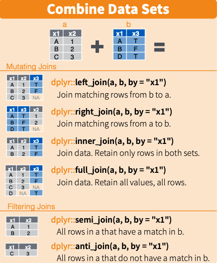

##### [[source]](https://rstudio.com/wp-content/uploads/2015/02/data-wrangling-cheatsheet.pdf)

There are several types of `*_join()` functions to consider. The `full_join()` function keeps all rows from both tibbles that are being joined and adds `NA` values as necessary if there are values within the key for either of the tibbles that is is not in the key of the other tibble.

We use the `full_join()` function as we have different time spans for each dataset and we would like to retain as much data as possible.

The `full_join()` function will simply create `NA` values for any of the years that are not in one of the datasets.

First, we check using the base `summary()` function that there are column names that are consistent in each dataset that we wish to combine.

```r
summary(CO2_emissions)
```

```
   Country               Year        Emissions           Label
 Length:50688       Min.   :1751   Min.   :       0   Length:50688
 Class :character   1st Qu.:1817   1st Qu.:     550   Class :character
 Mode  :character   Median :1882   Median :    4390   Mode  :character
                    Mean   :1882   Mean   :   83808
                    3rd Qu.:1948   3rd Qu.:   31925
                    Max.   :2014   Max.   :10300000
                                   NA's   :33772
```

```r
summary(gdp_growth)
```

```
   Country               Year           GDP             Label
 Length:42486       Min.   :1801   Min.   :-67.500   Length:42486
 Class :character   1st Qu.:1855   1st Qu.:  0.133   Class :character
 Mode  :character   Median :1910   Median :  0.633   Mode  :character
                    Mean   :1910   Mean   :  1.302
                    3rd Qu.:1965   3rd Qu.:  2.160
                    Max.   :2019   Max.   :145.000
                                   NA's   :2392
```

```r
summary(energy_use)
```

```
   Country               Year          Energy            Label
 Length:9464        Min.   :1960   Min.   :    9.58   Length:9464
 Class :character   1st Qu.:1974   1st Qu.:  505.75   Class :character
 Mode  :character   Median :1988   Median : 1185.00   Mode  :character
                    Mean   :1988   Mean   : 2238.82
                    3rd Qu.:2001   3rd Qu.: 3030.00
                    Max.   :2015   Max.   :22000.00
                                   NA's   :3544
```

**Question Opportunity**

What variable or variables might we want to use to join our data by?

**Click here to see an explanation for what variable or variables to join by after you have thought about it.**

The `Country`, and `Year` variables are present in all of the datasets with values that overlap. Although `Label` is also present in the datasets, the values do not overlap. We can see that the minimum and maximum year is different for nearly all the datasets.

Next, we need to specify what columns/variables we will be joining by using the `by =` argument in the `full_join()` function, (recall that this variable is called the “key”)

```r
data_wide <- CO2_emissions %>%
  full_join(gdp_growth, by = c("Country", "Year", "Label")) %>%
  full_join(energy_use, by = c("Country", "Year", "Label"))

set.seed(123)

data_wide %>%
  slice_sample(n = 6)
```

```
# A tibble: 6 × 6
  Country                   Year Emissions Label                      GDP Energy
  <chr>                    <dbl>     <dbl> <chr>                    <dbl>  <dbl>
1 Angola                    1899        NA GDP Growth/Capita (%)    0.425     NA
2 Central African Republic  1974        NA GDP Growth/Capita (%)   -4.92      NA
3 Bahamas                   1832        NA CO2 Emissions (Metric … NA         NA
4 Montenegro                1843        NA CO2 Emissions (Metric … NA         NA
5 Croatia                   2015        NA Energy Use (kg, oil-eq… NA         NA
6 Israel                    1885        NA GDP Growth/Capita (%)    0.582     NA
```

**Click here to see an explanation for another option that works well for large numbers of tibbles**

We can also do the same thing by using the `reduce()` function of the `purrr` package. This takes a list of elements (which can be tibbles) and then applies a function that requires two inputs iteratively using the first pair of elements and creating a single element and then applying the function again to the output element and the next listed element and so on and so forth.

You can see that this is a great option if you have many datasets to combine!

```r
data_wide <- data_wide %>%
  list(CO2_emissions, gdp_growth, energy_use) %>%
  reduce(full_join, by = c("Country", "Year", "Label"))

set.seed(123)

data_wide %>%
  slice_sample(n = 6)
```

```
# A tibble: 6 × 9
  Country     Year Emissions.x Label  GDP.x Energy.x Emissions.y  GDP.y Energy.y
  <chr>      <dbl>       <dbl> <chr>  <dbl>    <dbl>       <dbl>  <dbl>    <dbl>
1 Angola      1899          NA GDP …  0.425       NA          NA  0.425       NA
2 Central A…  1974          NA GDP … -4.92        NA          NA -4.92        NA
3 Bahamas     1832          NA CO2 … NA           NA          NA NA           NA
4 Montenegro  1843          NA CO2 … NA           NA          NA NA           NA
5 Croatia     2015          NA Ener… NA           NA          NA NA           NA
6 Israel      1885          NA GDP …  0.582       NA          NA  0.582       NA
```

```r
data_wide %>%
  glimpse()
```

```
Rows: 102,638
Columns: 9
$ Country     <chr> "Afghanistan", "Afghanistan", "Afghanistan", "Afghanistan"…
$ Year        <dbl> 1751, 1752, 1753, 1754, 1755, 1756, 1757, 1758, 1759, 1760…
$ Emissions.x <dbl> NA, NA, NA, NA, NA, NA, NA, NA, NA, NA, NA, NA, NA, NA, NA…
$ Label       <chr> "CO2 Emissions (Metric Tons)", "CO2 Emissions (Metric Tons…
$ GDP.x       <dbl> NA, NA, NA, NA, NA, NA, NA, NA, NA, NA, NA, NA, NA, NA, NA…
$ Energy.x    <dbl> NA, NA, NA, NA, NA, NA, NA, NA, NA, NA, NA, NA, NA, NA, NA…
$ Emissions.y <dbl> NA, NA, NA, NA, NA, NA, NA, NA, NA, NA, NA, NA, NA, NA, NA…
$ GDP.y       <dbl> NA, NA, NA, NA, NA, NA, NA, NA, NA, NA, NA, NA, NA, NA, NA…
$ Energy.y    <dbl> NA, NA, NA, NA, NA, NA, NA, NA, NA, NA, NA, NA, NA, NA, NA…
```

We will also make a long version of this data, where we will create an new variable called `Indicator` that will indicate what dataset the data came from.

**Question Opportunity**

Try to come up with the code to do this.

**Click here to reveal the code.**

```r
data_long <- data_wide %>%
  pivot_longer(cols = c(-Country, -Year, -Label),
               names_to = "Indicator",
               values_to = "Value")
```

```r
set.seed(123)

data_long %>%
  slice_sample(n = 6)
```

```
# A tibble: 6 × 5
  Country    Year Label                       Indicator   Value
  <chr>     <dbl> <chr>                       <chr>       <dbl>
1 Nepal      1825 CO2 Emissions (Metric Tons) GDP.x          NA
2 Jordan     1917 CO2 Emissions (Metric Tons) Energy.y       NA
3 Iraq       1829 CO2 Emissions (Metric Tons) GDP.x          NA
4 Samoa      1982 CO2 Emissions (Metric Tons) Emissions.y   114
5 Denmark    1907 GDP Growth/Capita (%)       Emissions.x    NA
6 Nicaragua  1814 CO2 Emissions (Metric Tons) Emissions.x    NA
```

We will now combine this data with the US data about disasters and temperatures.

```r
us_disaster %>%
  slice_head(n = 6)
```

```
# A tibble: 6 × 5
   Year Country       Indicator Value Label
  <dbl> <chr>         <chr>     <dbl> <chr>
1  1980 United States Disasters     3 Number of Disasters
2  1981 United States Disasters     2 Number of Disasters
3  1982 United States Disasters     3 Number of Disasters
4  1983 United States Disasters     5 Number of Disasters
5  1984 United States Disasters     2 Number of Disasters
6  1985 United States Disasters     5 Number of Disasters
```

```r
us_temperature %>%
  slice_head(n = 6)
```

```
# A tibble: 6 × 5
   Year Country       Indicator   Value Label
  <dbl> <chr>         <chr>       <dbl> <chr>
1  1895 United States Temperature  50.3 Temperature (Fahrenheit)
2  1896 United States Temperature  52.0 Temperature (Fahrenheit)
3  1897 United States Temperature  51.6 Temperature (Fahrenheit)
4  1898 United States Temperature  51.4 Temperature (Fahrenheit)
5  1899 United States Temperature  51.0 Temperature (Fahrenheit)
6  1900 United States Temperature  52.8 Temperature (Fahrenheit)
```

We will now use the `bind_rows()` function of the `dplyr` package which will just append the `us_temperature` data and the `us_disaster` data after the `data_long` data.

```r
data_long <- data_long %>%
  list(data_long, us_disaster, us_temperature) %>%
  bind_rows() %>%
  mutate(Country = as.factor(Country))
```

We also converted the `Country` column to a factor in the last line of the code chunk.

We can check the top and bottom of the new `data_long` tibble to see that our `us_temperature` data is at the bottom. To see the end of our tibble we can use `slice_tail()` function of the `dplyr` package.

```r
data_long %>%
  slice_head(n = 6)
```

```
# A tibble: 6 × 5
  Country      Year Label                       Indicator   Value
  <fct>       <dbl> <chr>                       <chr>       <dbl>
1 Afghanistan  1751 CO2 Emissions (Metric Tons) Emissions.x    NA
2 Afghanistan  1751 CO2 Emissions (Metric Tons) GDP.x          NA
3 Afghanistan  1751 CO2 Emissions (Metric Tons) Energy.x       NA
4 Afghanistan  1751 CO2 Emissions (Metric Tons) Emissions.y    NA
5 Afghanistan  1751 CO2 Emissions (Metric Tons) GDP.y          NA
6 Afghanistan  1751 CO2 Emissions (Metric Tons) Energy.y       NA
```

```r
data_long %>%
  slice_tail(n = 6)
```

```
# A tibble: 6 × 5
  Country        Year Label                    Indicator   Value
  <fct>         <dbl> <chr>                    <chr>       <dbl>
1 United States  2014 Temperature (Fahrenheit) Temperature  52.5
2 United States  2015 Temperature (Fahrenheit) Temperature  54.4
3 United States  2016 Temperature (Fahrenheit) Temperature  54.9
4 United States  2017 Temperature (Fahrenheit) Temperature  54.6
5 United States  2018 Temperature (Fahrenheit) Temperature  53.5
6 United States  2019 Temperature (Fahrenheit) Temperature  52.7
```

```r
set.seed(123)

data_long %>%
  slice_sample(n = 10)
```

```
# A tibble: 10 × 5
   Country        Year Label                           Indicator       Value
   <fct>         <dbl> <chr>                           <chr>           <dbl>
 1 Jordan         1917 CO2 Emissions (Metric Tons)     Energy.y       NA
 2 Zambia         1859 GDP Growth/Capita (%)           Energy.y       NA
 3 Cuba           1975 CO2 Emissions (Metric Tons)     Emissions.x 27100
 4 Senegal        1868 GDP Growth/Capita (%)           GDP.x           0.469
 5 India          1830 GDP Growth/Capita (%)           Energy.y       NA
 6 Ireland        1990 Energy Use (kg, oil-eq./capita) Energy.y     2820
 7 United States  1978 Temperature (Fahrenheit)        Temperature    51.0
 8 Tajikistan     1974 CO2 Emissions (Metric Tons)     Energy.x       NA
 9 Chad           1991 CO2 Emissions (Metric Tons)     Energy.x       NA
10 Benin          1978 GDP Growth/Capita (%)           GDP.x           0.277
```

**Click here for details about the difference between `full_join()` and `bind_rows()`**

The difference between this function and the `full_join()` function is that the `bind_rows()` function will essentially just append each dataset to each other, whereas the `full_join()` function collapses data that is comparable. Here, you will see an example of what the data would have been like for `data_wide` if we had made it using `bind_rows()` and if `full_join()` had been used but was not joined by the `Label` variable. Since the `Label` variable has unique values for each type of `Indicator`, this causes the `full_join()` result to be the same as `bind_rows()`.

Let’s consider an example and look at the values for China in the year of 1980.

First we will use the `bind_rows()` function which automatically creates `NA` values for any variable that is missing from a data object that is added by combining the data object with another that contains that missing variable using this function.

```r
data_wide_br <-
  list(CO2_emissions, gdp_growth, energy_use) %>%
  bind_rows()

data_wide_br %>%
 filter(Country == "China",
           Year == 1980)
```

```
# A tibble: 3 × 6
  Country  Year Emissions Label                             GDP Energy
  <chr>   <dbl>     <dbl> <chr>                           <dbl>  <dbl>
1 China    1980   1470000 CO2 Emissions (Metric Tons)     NA        NA
2 China    1980        NA GDP Growth/Capita (%)            2.16     NA
3 China    1980        NA Energy Use (kg, oil-eq./capita) NA       609
```

We see that we have three rows of data.

Now we will use the `full_join()` function two ways. First we will combine by `Country` and `Year` and `Label`.

```r
data_wide_fj_label <-
  list(CO2_emissions, gdp_growth, energy_use) %>%
  reduce(full_join, by = c("Country", "Year", "Label"))

data_wide_fj_label %>%
  filter(Country == "China", Year == "1980")
```

```
# A tibble: 3 × 6
  Country  Year Emissions Label                             GDP Energy
  <chr>   <dbl>     <dbl> <chr>                           <dbl>  <dbl>
1 China    1980   1470000 CO2 Emissions (Metric Tons)     NA        NA
2 China    1980        NA GDP Growth/Capita (%)            2.16     NA
3 China    1980        NA Energy Use (kg, oil-eq./capita) NA       609
```

Again we have 3 rows of data. The data produced by `bind_rows()` and `full_join()` is identical (which we can check by using the `setequal()` function of the `dplyr` package) and has the same dimensions (which we can check by using the `dim()` base function).

```r
dim(data_wide_br)
```

```
[1] 102638      6
```

```r
dim(data_wide_fj_label)
```

```
[1] 102638      6
```

```r
setequal(data_wide_fj_label, data_wide_br)
```

```
[1] TRUE
```

However, now we will join by only `Country` and `Year`:

```r
data_wide_fj <-
  list(CO2_emissions, gdp_growth, energy_use) %>%
  reduce(full_join, by = c("Country", "Year"))

data_wide_fj %>%
  filter(Country == "China", Year == "1980")
```

```
# A tibble: 1 × 8
  Country  Year Emissions Label.x                       GDP Label.y Energy Label
  <chr>   <dbl>     <dbl> <chr>                       <dbl> <chr>    <dbl> <chr>
1 China    1980   1470000 CO2 Emissions (Metric Tons)  2.16 GDP Gr…    609 Ener…
```

Now we see that we have only a single row. The data that corresponds to the same year and country has been collapsed into a single but wider row.

This is something to keep in mind when you are wrangling your data. The choice of what function to use and how should depend on how you want the data to be after you combine the different sources of data together.

We have a few more things to do before we leave the data wrangling section.

We will create a new variable called `Region` that will indicate if the data is about the United States or a different country based on the values in the `Country` variable. To do this, we will use the `case_when()` function of the `dplyr` package.

For example, if the `Country` variable is equal to `"United States"` the value for the new variable will also be `"United States"`, where as if the `Country` variable is not equal to `"United States"` but is some other character string value, such as `"Afghanistan"`, then the value for the new variable will be `"Rest of the World"`. We can specify that something is not equal by using the `!=` operator.

The new values for the new variable `Region` are indicated after the specific conditional statements by using the `~` symbol.

```r
data_long <- data_long %>%
  mutate(Region = case_when(Country == "United States" ~ "United States",
                            Country != "United States" ~ "Rest of the World"))

data_long  %>%
  arrange(Country) %>%
  slice_head(n = 6)
```

```
# A tibble: 6 × 6
  Country      Year Label                       Indicator   Value Region
  <fct>       <dbl> <chr>                       <chr>       <dbl> <chr>
1 Afghanistan  1751 CO2 Emissions (Metric Tons) Emissions.x    NA Rest of the W…
2 Afghanistan  1751 CO2 Emissions (Metric Tons) GDP.x          NA Rest of the W…
3 Afghanistan  1751 CO2 Emissions (Metric Tons) Energy.x       NA Rest of the W…
4 Afghanistan  1751 CO2 Emissions (Metric Tons) Emissions.y    NA Rest of the W…
5 Afghanistan  1751 CO2 Emissions (Metric Tons) GDP.y          NA Rest of the W…
6 Afghanistan  1751 CO2 Emissions (Metric Tons) Energy.y       NA Rest of the W…
```

We can also remove rows for countries with `NA` values using the `drop_na()` function of the `tidyr` package to drop all years with missing data.

```r
data_long_with_miss <-
  data_long %>%
  arrange(Country)

data_long <- data_long %>%
  drop_na() %>%
  arrange(Country)
```

You can see that by removing the NA values the data for Afghanistan starts at 1949 instead of 1751.

```r
data_long %>%
  slice_head(n = 6)
```

```
# A tibble: 6 × 6
  Country      Year Label                       Indicator   Value Region
  <fct>       <dbl> <chr>                       <chr>       <dbl> <chr>
1 Afghanistan  1949 CO2 Emissions (Metric Tons) Emissions.x  14.7 Rest of the W…
2 Afghanistan  1949 CO2 Emissions (Metric Tons) Emissions.y  14.7 Rest of the W…
3 Afghanistan  1950 CO2 Emissions (Metric Tons) Emissions.x  84.3 Rest of the W…
4 Afghanistan  1950 CO2 Emissions (Metric Tons) Emissions.y  84.3 Rest of the W…
5 Afghanistan  1951 CO2 Emissions (Metric Tons) Emissions.x  91.7 Rest of the W…
6 Afghanistan  1951 CO2 Emissions (Metric Tons) Emissions.y  91.7 Rest of the W…
```

**Question Opportunity**

Using only data from the US, calculate the first and last year that a value was reported for each variable (e.g. CO2 emissions, energy use, etc).

**Hint** : Use the `group_by()` and `summarize()` functions in the `dplyr` package.

To allow users to skip import and wrangling we will save the data as an RDA file as well as a CSV file as this is often useful to send our data to collaborators. We will save this in a “wrangled” subdirectory of our “data” directory of our working directory.

```r
save(data_long, file = here::here("data", "wrangled", "wrangled_data.rda"))
readr::write_csv(data_long, path = here::here("data","wrangled", "wrangled_data.csv"))
```

# **Data Visualization**

If you have been following along but stopped, we could load our wrangled data like so:

```r
load(here::here("data", "wrangled", "wrangled_data.rda"))
```

**If you skipped the data wrangling section click here.**

First you need to install and load the `OCSdata` package:

```r
# install.packages("OCSdata")
# You will need to install the package if you haven't already done so.
library(OCSdata)
```

Then, you may load the wrangled data using the following code:

```r
wrangled_rda("ocs-bp-co2-emissions", outpath = getwd())
load(here::here("OCSdata", "data", "wrangled", "wrangled_data.rda"))
```

If the package does not work for you, alternatively, an RDA file (stands for R data) of the data can be found [here](https://github.com//opencasestudies/ocs-bp-co2-emissions/tree/master/data/wrangled) or slightly more directly [here](https://raw.githubusercontent.com/opencasestudies/ocs-bp-co2-emissions/master/data/wrangled/wrangled_data.rda). Download this file and then place it in your current working directory within a subdirectory called “wrangled” within a subdirectory called “data” to copy and paste our code. We used an RStudio project and the [`here` package](https://github.com/jennybc/here_here) to navigate to the file more easily.

```r
load(here::here("data", "wrangled", "wrangled_data.rda"))
```

**Click here to see more about creating new projects in RStudio.**

See [here](https://support.rstudio.com/hc/en-us/articles/200526207-Using-Projects) to learn more about using RStudio projects and here to learn more about the `here` package.

Now we will create some simple plots to examine the CO2 emissions over time using the `ggplot2` package.

As you may have already seen, there are many functions available in base R that can create plots (e.g. `plot()`, `boxplot()`). Others include: `hist()`, `qqplot()`, etc. These functions are great because they come with a basic installation of R and can be quite powerful when you need a quick visualization of something when you are exploring data.

We are choosing to introduce `ggplot2` because, in our opinion, it is one of the simplest ways for beginners to create relatively complicated plots that are intuitive and aesthetically pleasing.

## **The `ggplot2` R package**

The reasons [`ggplot2`](http://ggplot2.tidyverse.org) is generally intuitive for beginners is the use of [grammar of graphics](http://vita.had.co.nz/papers/layered-grammar.html) or the `gg` in `ggplot2`. The idea is that you can construct many sentences by learning just a few nouns, adjectives, and verbs. There are specific “words” that we will introduce, and once you are comfortable with them, you will be able to create (or “write”) hundreds of different plots.

The critical part to making graphics using `ggplot2` is the data needs to be in a *tidy* format. Given that we have just spent time putting our data in *tidy* format, we are primed to take advantage of all that `ggplot2` has to offer!

We will show how it is easy to pipe *tidy* data (output) as input to other functions that create plots. This all works because we are working within the *tidyverse*.

#### What is the `ggplot()` function?

As explained by Hadley Wickham:

> the grammar tells us that a statistical graphic is a mapping from data to aesthetic attributes (colour, shape, size) of geometric objects (points, lines, bars). The plot may also contain statistical transformations of the data and is drawn on a specific coordinates system.

#### `ggplot2` Terminology

- **ggplot** - the main function where you specify the dataset and variables to plot (this is where we define the `x` and `y` variable names)
- **geoms** - geometric objects
  - e.g. `geom_point()`, `geom_bar()`, `geom_line()`, `geom_histogram()`
- **aes** - aesthetics
  - shape, transparency, color, fill, line types
- **scales** - define how your data will be plotted
  - continuous, discrete, log, etc

The function `aes()` is an aesthetic mapping function inside the `ggplot()` object. We use this function to specify plot attributes (e.g. `x` and `y` variable names) that will not change as we add more layers.

Anything that goes in the `ggplot()` object becomes a global setting. From there, we use the `geom` objects to add more layers to the base `ggplot()` object. These will define what we are interested in illustrating using the data.

## **CO2 Emissions**

Let’s start by plotting the CO2 emissions over time. Because our dataset contains other variables, we first need to filter our data to only include the CO2 emissions data by using the `filter()` function of the `dplyr` package. To use this function we need to specify what value (e.g. `Emissions`) we want for a given variable or column (e.g. `Indicator`).

In this case, we filter to keep all rows where the `Indicator` variable is equal to the word `Emissions`. Notice that this needs to be in quotes, while the variable name does not.

```r
data_long %>%
  filter(Indicator == "Emissions")
```

```
# A tibble: 16,916 × 6
   Country      Year Label                       Indicator Value Region
   <fct>       <dbl> <chr>                       <chr>     <dbl> <chr>
 1 Afghanistan  1949 CO2 Emissions (Metric Tons) Emissions  14.7 Rest of the Wo…
 2 Afghanistan  1950 CO2 Emissions (Metric Tons) Emissions  84.3 Rest of the Wo…
 3 Afghanistan  1951 CO2 Emissions (Metric Tons) Emissions  91.7 Rest of the Wo…
 4 Afghanistan  1952 CO2 Emissions (Metric Tons) Emissions  91.7 Rest of the Wo…
 5 Afghanistan  1953 CO2 Emissions (Metric Tons) Emissions 106   Rest of the Wo…
 6 Afghanistan  1954 CO2 Emissions (Metric Tons) Emissions 106   Rest of the Wo…
 7 Afghanistan  1955 CO2 Emissions (Metric Tons) Emissions 154   Rest of the Wo…
 8 Afghanistan  1956 CO2 Emissions (Metric Tons) Emissions 183   Rest of the Wo…
 9 Afghanistan  1957 CO2 Emissions (Metric Tons) Emissions 293   Rest of the Wo…
10 Afghanistan  1958 CO2 Emissions (Metric Tons) Emissions 330   Rest of the Wo…
# ℹ 16,906 more rows
```

We also need to sum the emissions across countries for each year. Here, we use the `group_by()` and `summarize()` function that we previously learned about.

```r
data_long %>%
  filter(Indicator == "Emissions") %>%
  group_by(Year) %>%
  summarize(Emissions = sum(Value))
```

```
# A tibble: 264 × 2
    Year Emissions
   <dbl>     <dbl>
 1  1751      9360
 2  1752      9360
 3  1753      9360
 4  1754      9370
 5  1755      9370
 6  1756     10000
 7  1757     10000
 8  1758     10000
 9  1759     10000
10  1760     10000
# ℹ 254 more rows
```

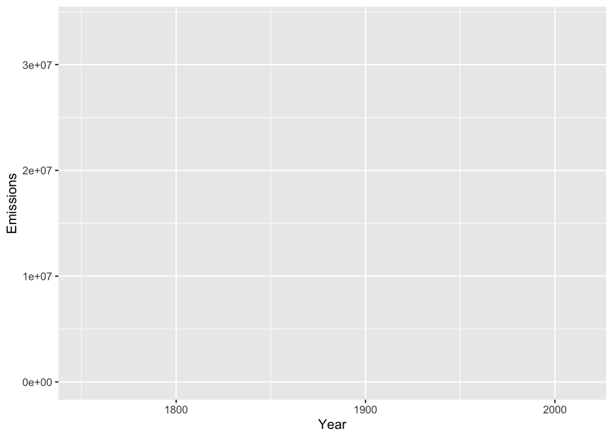

```r
data_long %>%
  filter(Indicator == "Emissions") %>%
  group_by(Year) %>%
  summarize(Emissions = sum(Value)) %>%
  ggplot(aes(x = Year, y = Emissions))
```

Looks like we got a blank plot. What happened? We need to tell R what *type of plot* we want. To do that, we need to add another layer to define how we want the plot to look. We do so by using the `+` sign in between each command.

### Line plots

To tell R what type of plot we want, we need to add another *layer* to our ggplot object. To add a type of plot, we can use one of the many `geom_*` functions in `ggplot2`. For example, type `geom` into the RStudio console and you will see many options to scroll through.

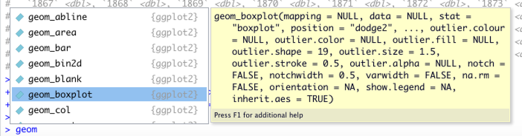

Here, we will use the `geom_line()` function because we would like to create a line plot. We also use the `size` argument in `geom_line()` to control the size of the line.

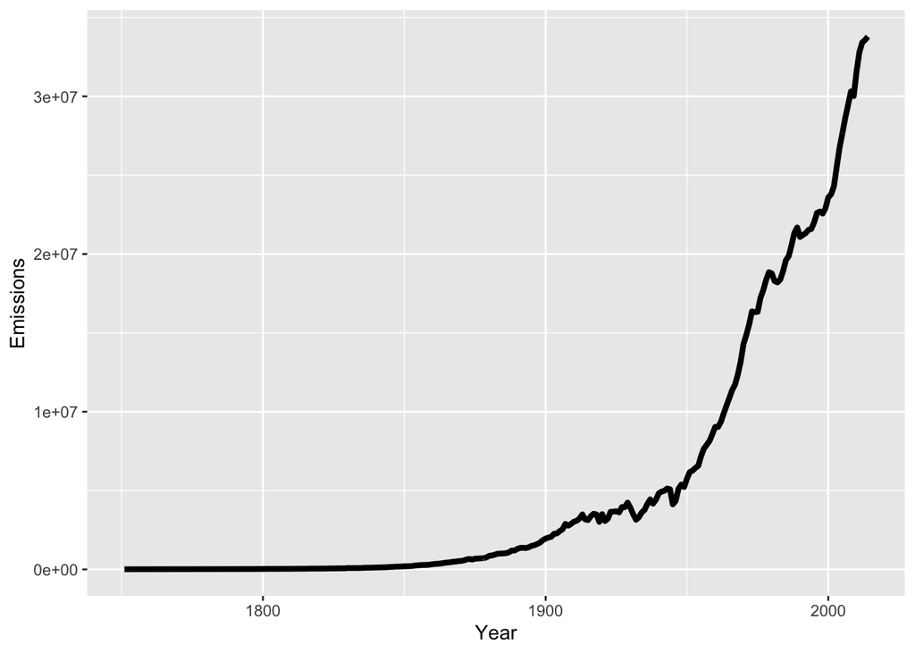

```r
data_long %>%
  filter(Indicator == "Emissions") %>%
  group_by(Year) %>%
  summarize(Emissions = sum(Value)) %>%
  ggplot(aes(x = Year, y = Emissions)) +
    geom_line(size = 1.5)
```

Wow, the CO2 is really rising sharply!

Finally, let’s make this plot really nice by adding a few final touches. To change title, caption, and the axis labels, we can use the `labs()` function. Again, notice that a plus sign is used between each layer that we add to the plot. To make CO2 appear with a subscript we can use `~CO[2]~`.

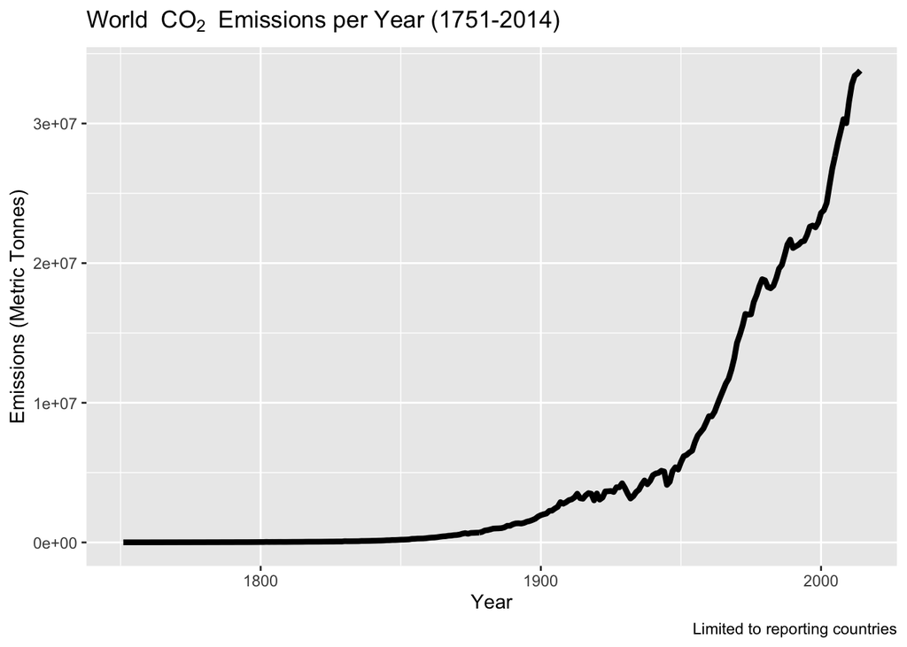

```r
data_long %>%
  filter(Indicator == "Emissions") %>%
  group_by(Year) %>%
  summarize(Emissions = sum(Value)) %>%
  ggplot(aes(x = Year, y = Emissions)) +
    geom_line(size = 1.5) +
    labs(title = "World " ~CO[2]~ " Emissions per Year (1751-2014)",
         caption = "Limited to reporting countries",
         y = "Emissions (Metric Tonnes)")
```

Next, we use the `theme()` function to change the font size of the x-axis, y-axis, axis titles, and the caption as shown below. To know what to call each element of the plot in this function to change the size type `?theme()` in the console.

You will see a very large list that includes other plot aspects like the background and the legend. This function can be used to modify your plot to your specifications.

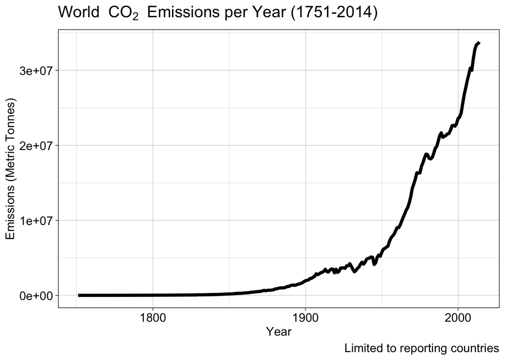

```r
data_long %>%
  filter(Indicator == "Emissions") %>%
  group_by(Year) %>%
  summarize(Emissions = sum(Value)) %>%
  ggplot(aes(x = Year, y = Emissions)) +
    geom_line(size = 1.5) +
    labs(title = "World " ~CO[2]~ " Emissions per Year (1751-2014)",
         caption = "Limited to reporting countries",
         y = "Emissions (Metric Tonnes)") +
  theme_linedraw() +
  theme(axis.text.x = element_text(size = 12),
        axis.text.y = element_text(size = 12),
       axis.title.x = element_text(size = 12),
       axis.title.y = element_text(size = 12),
       plot.caption = element_text(size = 12),
         plot.title = element_text(size = 16))
```

We can clearly see that global CO2 emissions have dramatically risen since 1900.

Notice, we used the function `theme_linedraw()` of `ggplot2` to change the general appearance of the plot.

**Useful tip**: You can type `theme_` in the RStudio console to see the various plot theme options available.

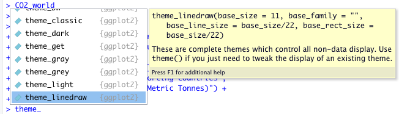

Great! We’ve created our first plot.

Before we leave this section, let’s save this theme so we do not have to keep typing the same code in future plots.

```r
my_theme <-
  theme_linedraw() +
  theme(axis.text.x = element_text(size = 12),
        axis.text.y = element_text(size = 12),
       axis.title.x = element_text(size = 12),
       axis.title.y = element_text(size = 12),
       plot.caption = element_text(size = 12),
         plot.title = element_text(size = 16))
```

In this way, we can just add another *layer* to our plot with the `my_theme` we created with the specifications of the sizes of the title and axis labels.

```r
CO2_world <-
  data_long %>%
  filter(Indicator == "Emissions") %>%
  group_by(Year) %>%
  summarize(Emissions = sum(Value)) %>%
  ggplot(aes(x = Year, y = Emissions)) +
    geom_line(size = 1.5) +
    labs(title = "World " ~CO[2]~ " Emissions per Year (1751-2014)",
         caption = "Limited to reporting countries",
         y = "Emissions (Metric Tonnes)") +
  my_theme
```

We are also saving the plot to an object called `CO2_world`. To show the plot we simply type the name of the object:

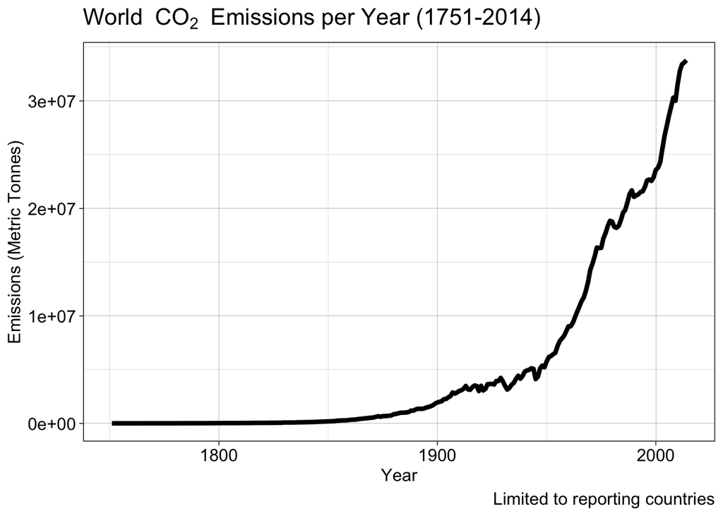

```r
CO2_world
```

Now let’s say we wanted to save this plot.

We could do so using the using the `save()` function to save this to a “plot” directory in our working directory as an RDA file and we can use the `png()` function to save a png for collaborators. We need to use `dev.off()` function to close the graphical device that we will use to create the png version of the plot so that we are ready to make another plot like this.

```r
save(CO2_world, file =here::here("plots", "CO2_world.rda"))
png(here::here("plots", "CO2_world.png"))
CO2_world
dev.off()
```

One thing that would be nice to know is which countries are contributing the most or the least to CO2 emissions. Let’s continue to explore the data to investigate how CO2 emissions from individual countries have changed over time.

Next, we go back to using our `data_long` dataset. Here, we use the `group` argument in `aes()` which controls whether a line should be drawn

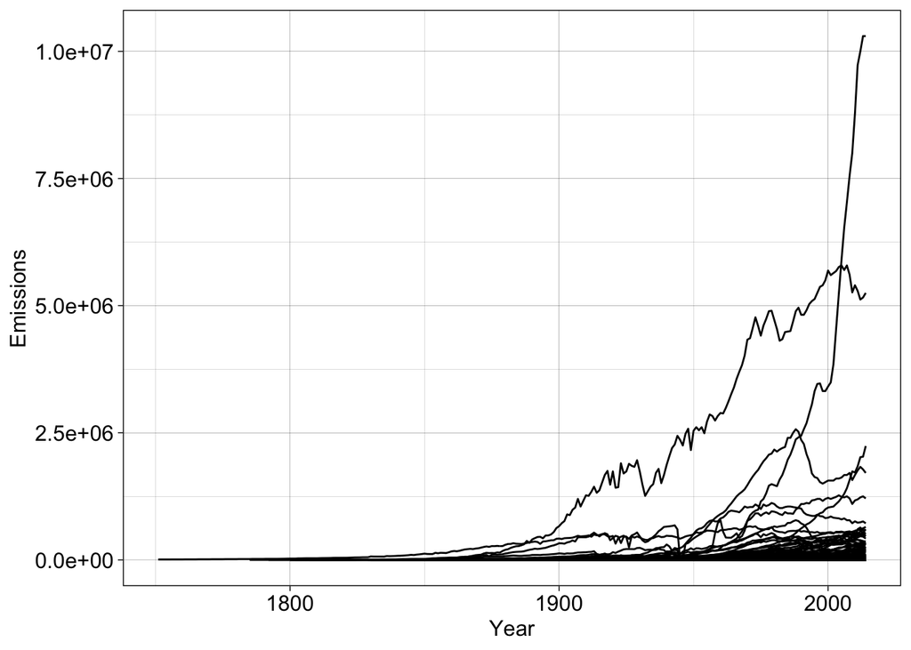

```r
data_long %>%
  filter(Indicator == "Emissions") %>%
  ggplot(aes(x = Year, y = Value, group = Country)) +
  geom_line() +
  ylab("Emissions") +
  my_theme
```

We can see that many countries show a dramatic increase in emissions over time with a handful of countries with particularly high levels.

**Question Opportunity**

- What happens when you do not use the `group = Country` argument?
- What other aesthetic (i.e. `aes()` arguments) can be changed?

Since we have many overlapping lines, we will make our lines slightly transparent by using the `alpha` argument.

This takes values from 0 to 1, where 0 is completely transparent and 1 is completely opaque.

We also add our `my_theme` controlling the size of the title and axis labels.

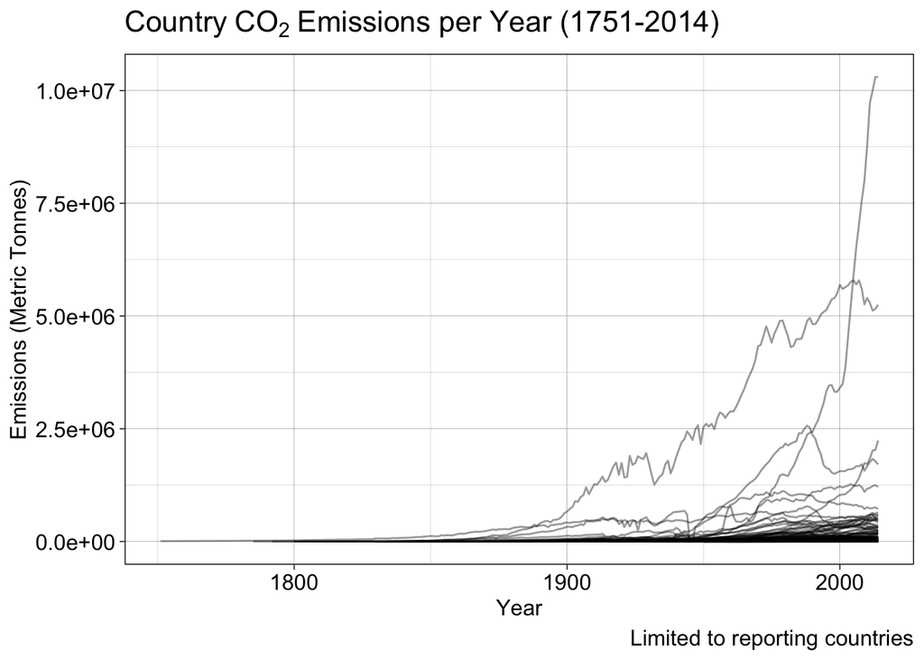

```r
CO2_countries <-
  data_long %>%
  filter(Indicator == "Emissions") %>%
  ggplot(aes(x = Year, y = Value, group = Country)) +
  geom_line(alpha = 0.4) +
  labs(title = "Country" ~CO[2]~ "Emissions per Year (1751-2014)",
     caption = "Limited to reporting countries",
           y = "Emissions (Metric Tonnes)") +
  my_theme

CO2_countries
```

Our plot is starting to look really good. One question you still might have is which country corresponds to which line? Which line indicates the emissions in the US?

### Adding color

We can add another “layer” on top of our first plot to add a blue line just for the US data. To do this we need to indicate what data we would like to plot, so we need to filter for just the US data and then we need to indicate that it will be colored by Country, even though in this case we only have one line to color. The default color would be a salmon pink color, but we would like blue. So we will use the `scale_color_manual()` function to manually choose the color that we want by using `scale_colour_manual(values = c("blue"))`. Often you might use red to highlight a subset of the data, however, this can be difficult for viewers with certain types of colorblindness.

Notice how the color name needs to be in quotes and that the argument `values =` is used to specify what color values to use.

We can add this line to the plot in two ways.

**Useful tip**: Instead of retyping the original code to create the `CO2_countries` plot, we can just use the `+` operator:

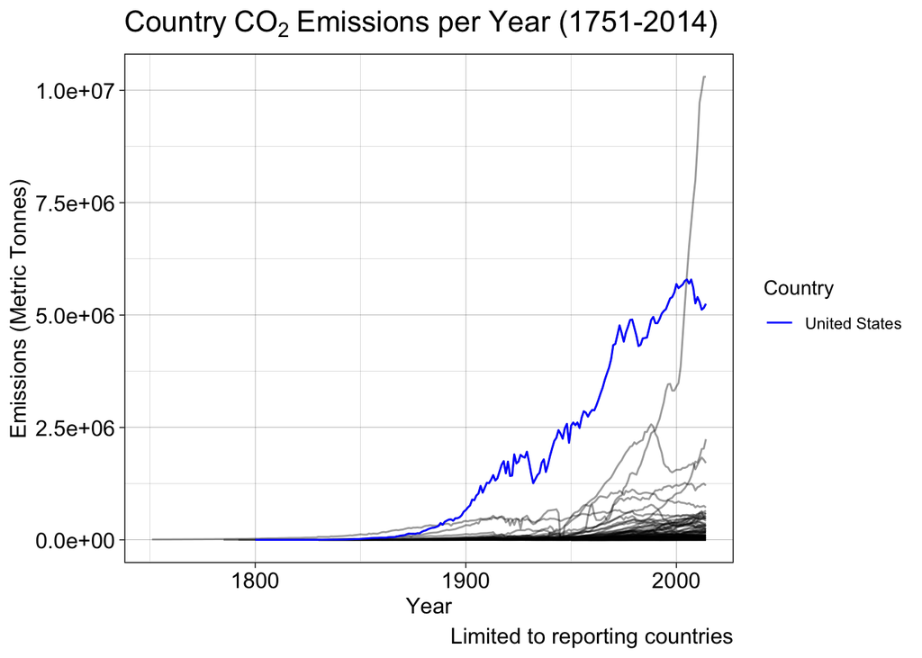

```r
CO2_countries +
  geom_line(data = data_long %>%
              filter(Indicator == "Emissions",
                     Country == "United States"),
              aes(x = Year, y = Value, color = Country)) +
  scale_colour_manual(values = c("blue"))
```

It looks like the US has long been the largest CO2 emission producing country until recently, when the US was surpassed by another country.

Let’s figure out who are the top 10 emission producing countries in 2014. Here, we filter the data for the year 2014, which was the final year of the data. Then, we can make a rank variable based on the `Value` variable for the amount of emissions produced.

There are many functions in the `dplyr` package for ranking values that are based on the SQL or specifically [SQL rank functions](https://www.sqlshack.com/overview-of-sql-rank-functions/). SQL is another programming language for managing large amounts of data. The difference in the rank functions mostly has to do with how to deal with ties in the data.  
We will use `dense_rank()`, as we do not want gaps between ranks.

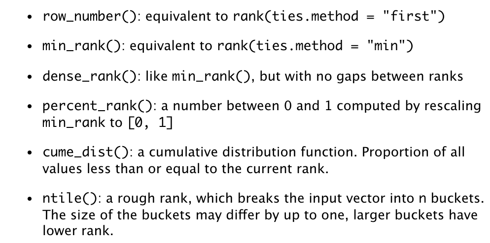

We want to do this in descending order because we want to rank by largest to smallest, so we will use the `desc()` function of the `dplyr` package. Then, we will arrange the output by rank using the `arrange()` function of the `dplyr` package.

```r
top_10_count <-
  data_long %>%
  filter(Indicator == "Emissions", Year == 2014) %>%
  mutate(rank = dense_rank(desc(Value))) %>%
  filter(rank <= 10) %>%
  arrange(rank)

top_10_count
```

```
# A tibble: 10 × 7
   Country        Year Label                       Indicator  Value Region  rank
   <fct>         <dbl> <chr>                       <chr>      <dbl> <chr>  <int>
 1 China          2014 CO2 Emissions (Metric Tons) Emissions 1.03e7 Rest …     1
 2 United States  2014 CO2 Emissions (Metric Tons) Emissions 5.25e6 Unite…     2
 3 India          2014 CO2 Emissions (Metric Tons) Emissions 2.24e6 Rest …     3
 4 Russia         2014 CO2 Emissions (Metric Tons) Emissions 1.71e6 Rest …     4
 5 Japan          2014 CO2 Emissions (Metric Tons) Emissions 1.21e6 Rest …     5
 6 Germany        2014 CO2 Emissions (Metric Tons) Emissions 7.20e5 Rest …     6
 7 Iran           2014 CO2 Emissions (Metric Tons) Emissions 6.49e5 Rest …     7
 8 Saudi Arabia   2014 CO2 Emissions (Metric Tons) Emissions 6.01e5 Rest …     8
 9 South Korea    2014 CO2 Emissions (Metric Tons) Emissions 5.87e5 Rest …     9
10 Canada         2014 CO2 Emissions (Metric Tons) Emissions 5.37e5 Rest …    10
```

We can see that China is now the top emission producing country.

**Question Opportunity**

What are the bottom 10 emission producing countries in 2014?

Let’s make a plot of *just these top ten countries*.

To do this, we need to filter the data to just these top countries by using the `%in%` operator to only keep countries in our `Country` variable that are also in the `Country` variable within `top_10_count`. We can use the `pull()` function also of the `dplyr` package to specifically grab just the `Country` data out of `top_10_count`.

Since we have 10 countries we will want to differentiate them by color.

To color our plot we will use the `viridis` color palette which is compatible with color-blindness by using the `scale_color_viridis_d()` function. This function is available by loading the `ggplot2` package. There are a few variations for discrete values as `_d`, or binned continuous values as `_b`, or continuous values as `_c`. See [here](https://ggplot2.tidyverse.org/reference/scale_viridis.html) for more information.

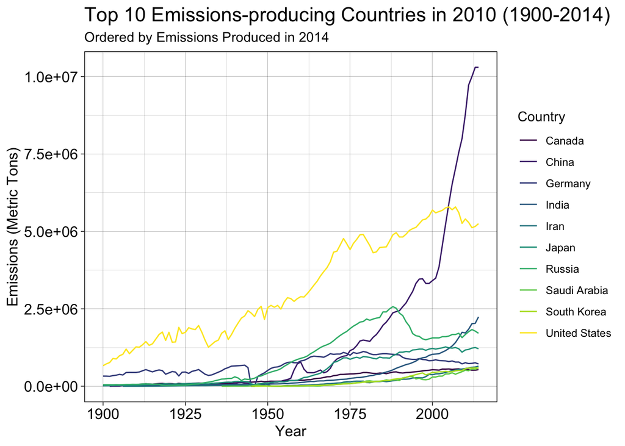

```r
Top10b <- data_long %>%
  filter(Country %in% pull(top_10_count, Country)) %>%
  filter(Indicator == "Emissions") %>%
  filter(Year >= 1900) %>%
  ggplot(aes(x = Year, y = Value, color = Country)) +
    geom_line() +
    scale_color_viridis_d() +
    labs(title = "Top 10 Emissions-producing Countries in 2010 (1900-2014)",
         subtitle = "Ordered by Emissions Produced in 2014",
         y = "Emissions (Metric Tons)",
         x = "Year") +
    my_theme

Top10b
```

It’s still a bit difficult to tell which line corresponds to which country. So, let’s add a text label directly to the plot. .

### Adding text labels

One way to do this is to add text layer to our plot using the `geom_text()` function of the `ggplot2` package. We need to first specify what variable or column we will use. However, we only want to pull the text labels for the top ten countries in the last year. To do this, we use the `last()` function of the `dplyr` package.

Then, we need to indicate that our text label will be based on the `Country` variable using the `aes()` aesthetics mapping argument. We will also get rid of our legend since we will not need it anymore, by using the `theme()` function of the `ggplot2` package.

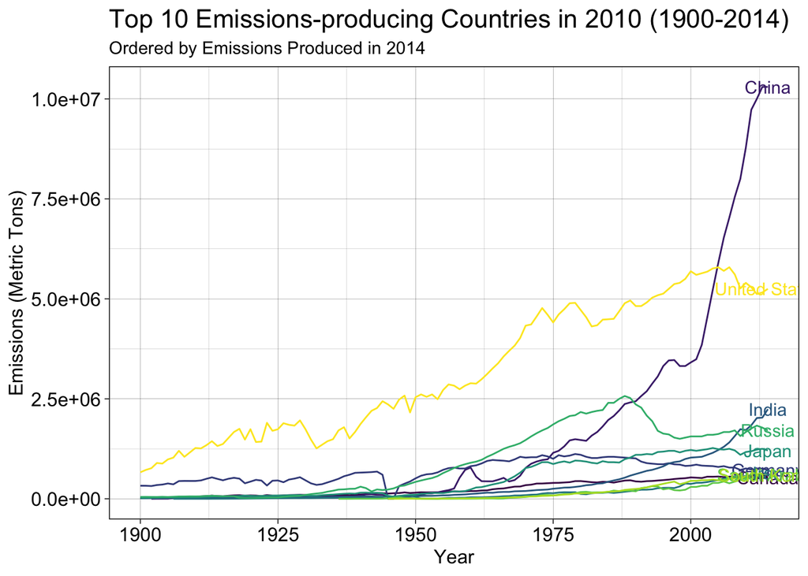

```r
Top10b +
  geom_text(data = data_long %>%
              filter(Country %in% pull(top_10_count, Country)) %>%
              filter(Indicator == "Emissions") %>%
              filter(Year == last(Year)),
            aes(label = Country)) +
  theme(legend.position = "none")
```

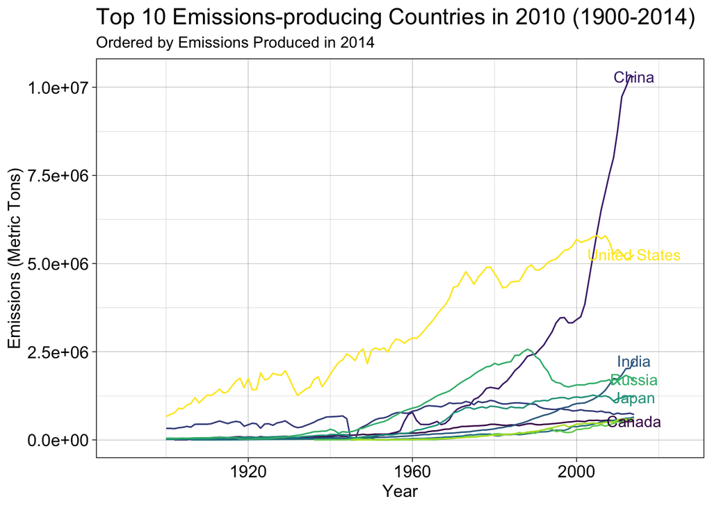

```r
Top10b +
  geom_text(data = data_long %>%
              filter(Country %in% pull(top_10_count, Country)) %>%
              filter(Indicator == "Emissions") %>%
              filter(Year == last(Year)),
            aes(label = Country),
            check_overlap = TRUE) +
  scale_x_continuous(expand = c(0.15, 0)) +
  theme(legend.position = "none")
```

This is easier to read now, but it also causes us to lose some of the labels. There are several alternative ways we can keep all of our labels and make them easier to read. The first package we will show is called `directlabels`.

The most simple option is to use the `direct.label()` function, which will automatically add labels at the end of the lines. However, it is a bit difficult to see some of our labels as they get automatically sized to fit the plot.

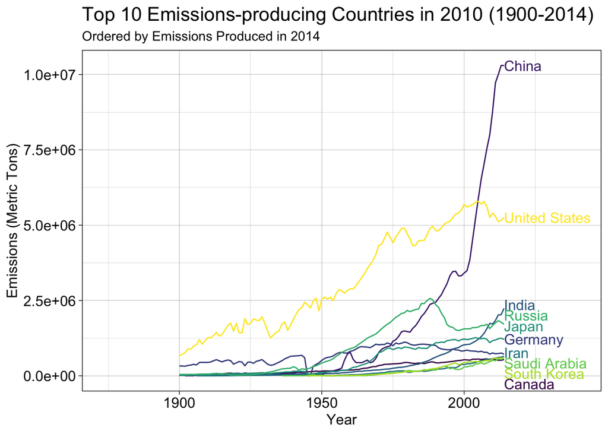

```r
direct.label(Top10b) +
  scale_x_continuous(expand = c(0.3, 0))
```

Alternatively this can be done within the `ggplot2` framework by layering using the `geom_dl()` function.

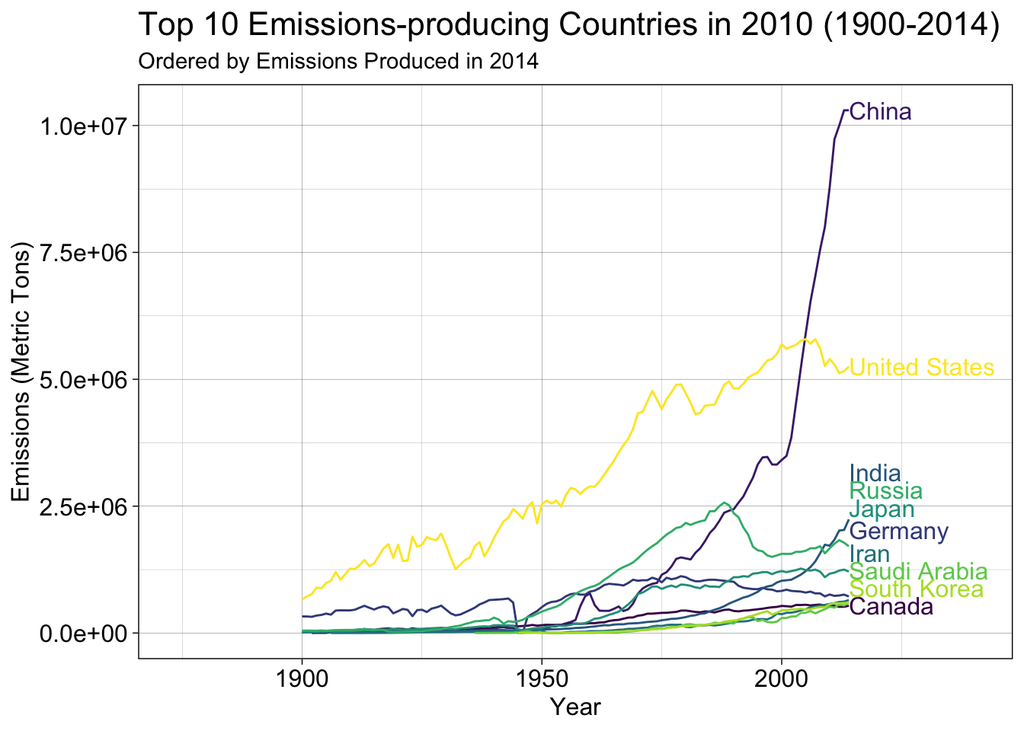

```r
Top10b +
  scale_x_continuous(expand = c(0.3, 0)) +
  geom_dl(aes(label = Country), method = list("last.points","bumpup")) +
  theme(legend.position = "none")
```

This is more legible now. We have all 10 countries names listed and they are in order of the last data point and they are relatively close to the lines that they correspond to.

Another option is to use a different method in the `directlables` package. [Here](http://directlabels.r-forge.r-project.org/docs/index.html) is a list of options.

For example, the `"angled.boxes"` method looks nice for some plots but does not work very well for our plot:

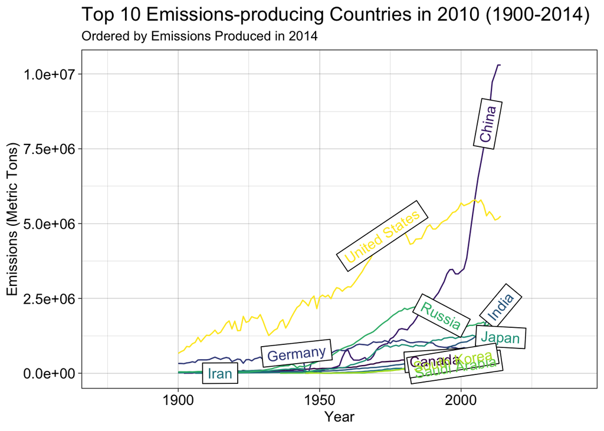

```r
direct.label(Top10b, method = list("angled.boxes")) +
  scale_x_continuous(expand = c(0.3, 0))
```

However the `"last.polygons"` method works quite well:

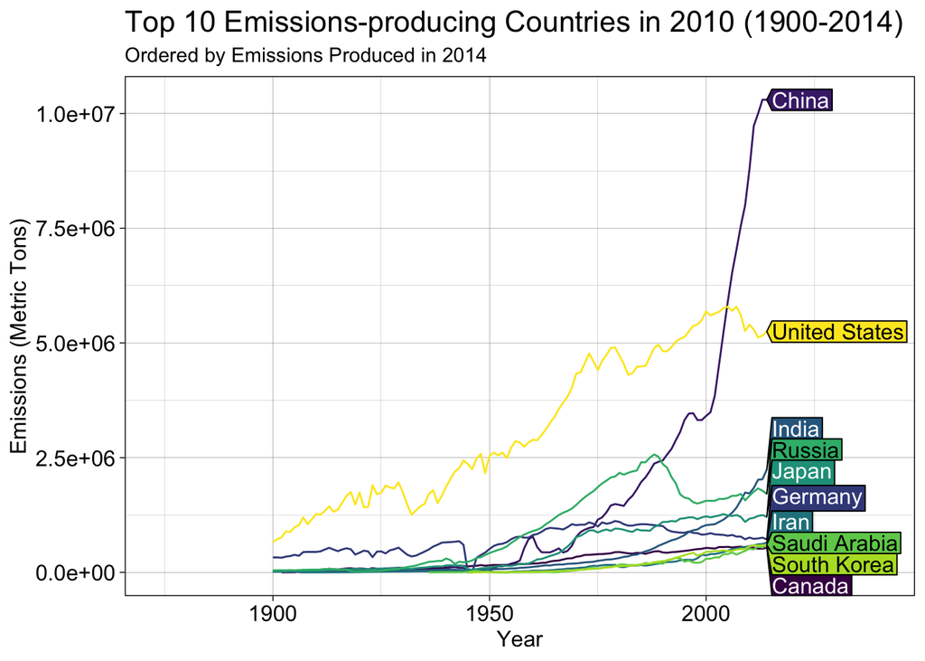

```r
direct.label(Top10b, method = list("last.polygons")) +
  scale_x_continuous(expand = c(0.3, 0))
```

The second package is the `ggrepel` package, which is especially good for crowded labels that might overlap one another. It allows for more control than the `directlabels` package.